# Deep Learning Systems (ENGR-E 533) Homework 5 , Fall 2021

**Name: Anitha Ganapathy**  
**Email: aganapa@iu.edu**

**Organize Import statements**

```python
#import some basic libraries

import numpy as np
import pandas as pd
import random
import math


import tensorflow as tf
from tensorflow.keras.callbacks import Callback
from tensorflow.keras.models import Sequential
from tensorflow.keras.losses import SparseCategoricalCrossentropy
from tensorflow.keras import layers, Model
from tensorflow.keras.utils import Sequence
from tensorflow.keras.activations import sigmoid
from tensorflow.keras.metrics import BinaryAccuracy
from tensorflow.keras.optimizers import Adam
from tensorflow import expand_dims
from tensorflow.python.ops.numpy_ops import np_config
from tensorflow.experimental.numpy.random import randint
from tensorflow.keras import initializers,callbacks

import keras
from keras.backend import count_params
from keras.datasets import mnist
from keras.datasets.fashion_mnist import load_data
from keras.models import Sequential
from keras.layers import Conv2DTranspose
from keras.layers import Activation, Flatten, Dense, Dropout, Input, LeakyReLU
from keras.layers import Dense, BatchNormalization, concatenate, Lambda, Reshape
from keras.layers.convolutional import Conv2D, MaxPooling2D
from keras.layers import Activation, Flatten, Dense, Dropout, InputLayer
from keras import backend as K
from keras.layers import Dense, Dropout, Flatten,BatchNormalization,Conv1D,MaxPool1D
from keras.layers import GRU,LSTM

# libraries for plotting

import matplotlib.pyplot as plt
%matplotlib inline

# from google.colab import drive

# drive.mount('/content/drive' ,force_remount =  True)
```

# Problem 1: RNNs as a generative model

## Load MNIST Data

```python
# the data, split between train and test sets
(x_train, y_train), (x_test, y_test) = keras.datasets.mnist.load_data()
```

```python
# Scale images to the [0, 1] range
x_train = x_train.astype("float32") / 255
x_test = x_test.astype("float32") / 255
```

## References

- https://www.kaggle.com/aritrag/consuming-data-with-tf-data
- https://stackoverflow.com/questions/40731433/understanding-tf-extract-image-patches-for-extracting-patches-from-an-image

```python
x_train.shape
```

```
(60000, 28, 28)
```

```python
plt.imshow(x_train[1])
```

[output not shown]

Divide every training image into 16 smaller patches. Since the original images are with 28×28 pixels, we need to divide the image into 7 × 7 patches. There is no overlap between those patches.Patches are ordered from the top left corner to the bottom right corner

https://stackoverflow.com/questions/40731433/understanding-tf-extract-image-patches-for-extracting-patches-from-an-image

```python
image = x_train[0]
plt.imshow(image)
```

[output not shown]

```python
# 7 x 7 patches for training data set
train_patches = tf.image.extract_patches(x_train[...,np.newaxis],
                           sizes=[1, 7, 7, 1],
                           strides=[1, 7, 7, 1],
                           rates=[1, 1, 1, 1],
                           padding= 'VALID')
```

```python
train_patches.shape
train_patches[0].shape
```

```
TensorShape([4, 4, 49])
```

```python
#7 x 7 patches for test data set
test_patches = tf.image.extract_patches(x_test[...,np.newaxis],
                           sizes=[1, 7, 7, 1],
                           strides=[1, 7, 7, 1],
                           rates=[1, 1, 1, 1],
                           padding= 'VALID')
```

```python
test_patches.shape
```

```
TensorShape([10000, 4, 4, 49])
```

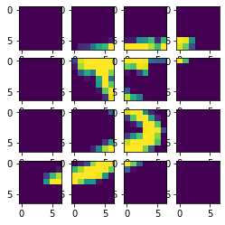

```python
#Vectorize each patch in training dataset from 7 × 7 to a 49-dimensional vector.
x_train1 = train_patches.numpy().reshape((-1, 16, 49))

plt.figure(figsize=(4, 4))
for col in range(16):
  plt.subplot(4, 4, col+1)
  plt.imshow(x_train1[0][col].reshape(7,7))
```

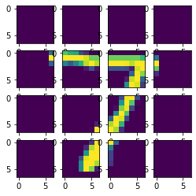

```python
#Vectorize each patch in test dataset from 7 × 7 to a 49-dimensional vector.
x_test1 = test_patches.numpy().reshape((-1, 16, 49))

plt.figure(figsize=(4, 4))
for col in range(16):
  plt.subplot(4, 4, col+1)
  plt.imshow(x_test1[0][col].reshape(7,7))
```

RNN LSTM Model

Train your RNN in a way that it can predict the next patch out of the so-far observed patches.

```python
# model = Sequential([
#           # Conv1D(filters=32, kernel_size=2, activation = 'relu', input_shape= (None,49)),
#           # MaxPool1D(pool_size=2, strides=2),
#           GRU(49,kernel_initializer=initializers.glorot_normal(),return_sequences=True, input_shape= (None,49)),
#           BatchNormalization(),
#           Dropout(0.8),
#           GRU(49,kernel_initializer=initializers.glorot_normal(),return_sequences=True),
#           BatchNormalization(),
#           Dropout(0.8),
#           GRU(49,kernel_initializer=initializers.glorot_normal(),return_sequences=True),
#           BatchNormalization(),
#           Dropout(0.8),
#           Dense(49,activation='tanh',kernel_initializer=initializers.glorot_normal())
# ])

input1 = layers.Input(shape=(None,49))
# Return states in addition to output
out1, h1, c1 = layers.LSTM(units= 32,activation='relu',return_sequences=True, return_state=True)(input1)
# We discard `outputs` and only keep the states.
states1 = [h1, c1]

# Pass the 2 states to a new LSTM layer, as initial state
out2, h2,c2 = layers.LSTM(units = 32,activation='relu',return_sequences=True, return_state=True)(out1, initial_state=states1)

final_output = layers.Dense(units = 49,activation='relu')(out2)

model = keras.Model(input1,final_output)
model.summary()


#Optimizer
opt = Adam(learning_rate=0.0001)
model.compile(loss=tf.keras.losses.BinaryCrossentropy(from_logits=True), metrics=['accuracy'],optimizer=opt)
# summarize layers
model.summary()
```

```
WARNING:tensorflow:Layer lstm_2 will not use cuDNN kernels since it doesn't meet the criteria. It will use a generic GPU kernel as fallback when running on GPU.
WARNING:tensorflow:Layer lstm_3 will not use cuDNN kernels since it doesn't meet the criteria. It will use a generic GPU kernel as fallback when running on GPU.
Model: "model_1"
__________________________________________________________________________________________________
 Layer (type)                   Output Shape         Param #     Connected to
==================================================================================================
 input_2 (InputLayer)           [(None, None, 49)]   0           []

 lstm_2 (LSTM)                  [(None, None, 32),   10496       ['input_2[0][0]']
                                 (None, 32),
                                 (None, 32)]

 lstm_3 (LSTM)                  [(None, None, 32),   8320        ['lstm_2[0][0]',
                                 (None, 32),                      'lstm_2[0][1]',
                                 (None, 32)]                      'lstm_2[0][2]']

 dense_1 (Dense)                (None, None, 49)     1617        ['lstm_3[0][0]']

==================================================================================================
Total params: 20,433
Trainable params: 20,433
Non-trainable params: 0
__________________________________________________________________________________________________
Model: "model_1"
__________________________________________________________________________________________________
 Layer (type)                   Output Shape         Param #     Connected to
==================================================================================================
 input_2 (InputLayer)           [(None, None, 49)]   0           []

 lstm_2 (LSTM)                  [(None, None, 32),   10496       ['input_2[0][0]']
                                 (None, 32),
                                 (None, 32)]

 lstm_3 (LSTM)                  [(None, None, 32),   8320        ['lstm_2[0][0]',
                                 (None, 32),                      'lstm_2[0][1]',
                                 (None, 32)]                      'lstm_2[0][2]']

 dense_1 (Dense)                (None, None, 49)     1617        ['lstm_3[0][0]']

==================================================================================================
Total params: 20,433
Trainable params: 20,433
Non-trainable params: 0
__________________________________________________________________________________________________
```

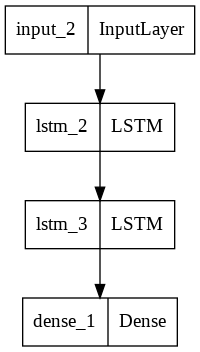

```python
tf.keras.utils.plot_model(model)
```

```python
# All patches except the last one
X_train=x_train1[:, :15, :]
X_train.shape
```

```
(60000, 15, 49)
```

```python
#All patches from the second to the last one excluding first
Y_train=x_train1[:, 1:, :]
Y_train.shape
```

```
(60000, 15, 49)
```

```python
# All patches except the last one
X_test=x_test1[:, :15, :]
X_test.shape
```

```
(10000, 15, 49)
```

```python
#All patches from the second to the last one excluding first
Y_test=x_test1[:, 1:, :]
Y_test.shape
```

```
(10000, 15, 49)
```

```python
X_train  = tf.convert_to_tensor(X_train)
Y_train = tf.convert_to_tensor(Y_train)
X_test = tf.convert_to_tensor(X_test)
Y_test = tf.convert_to_tensor(Y_test)
```

```python
%%time
#Train the network using mean squared error loss

model.compile(loss='mse',optimizer='adam', metrics=['accuracy'])
regenrative_gru = model.fit(X_train,Y_train,epochs =300 ,batch_size=100,validation_data=(X_test,Y_test),verbose = 2)
```

```
600/600 - 20s - loss: 0.0721 - accuracy: 0.1740 - val_loss: 0.0520 - val_accuracy: 0.2872 - 20s/epoch - 33ms/step
600/600 - 18s - loss: 0.0475 - accuracy: 0.3094 - val_loss: 0.0443 - val_accuracy: 0.3095 - 18s/epoch - 30ms/step
600/600 - 17s - loss: 0.0412 - accuracy: 0.3506 - val_loss: 0.0386 - val_accuracy: 0.3648 - 17s/epoch - 28ms/step
600/600 - 17s - loss: 0.0374 - accuracy: 0.3764 - val_loss: 0.0366 - val_accuracy: 0.4127 - 17s/epoch - 29ms/step
600/600 - 18s - loss: 0.0349 - accuracy: 0.3932 - val_loss: 0.0359 - val_accuracy: 0.4146 - 18s/epoch - 29ms/step
600/600 - 18s - loss: 0.0328 - accuracy: 0.4054 - val_loss: 0.0320 - val_accuracy: 0.4095 - 18s/epoch - 29ms/step
600/600 - 18s - loss: 0.0314 - accuracy: 0.4118 - val_loss: 0.0306 - val_accuracy: 0.4192 - 18s/epoch - 29ms/step
600/600 - 17s - loss: 0.0302 - accuracy: 0.4167 - val_loss: 0.0292 - val_accuracy: 0.4197 - 17s/epoch - 29ms/step
600/600 - 18s - loss: 0.0293 - accuracy: 0.4199 - val_loss: 0.0288 - val_accuracy: 0.4104 - 18s/epoch - 30ms/step
600/600 - 18s - loss: 0.0285 - accuracy: 0.4234 - val_loss: 0.0281 - val_accuracy: 0.4135 - 18s/epoch - 30ms/step
600/600 - 18s - loss: 0.0279 - accuracy: 0.4275 - val_loss: 0.0274 - val_accuracy: 0.4506 - 18s/epoch - 30ms/step
600/600 - 18s - loss: 0.0272 - accuracy: 0.4311 - val_loss: 0.0266 - val_accuracy: 0.4313 - 18s/epoch - 30ms/step
600/600 - 18s - loss: 0.0268 - accuracy: 0.4331 - val_loss: 0.0260 - val_accuracy: 0.4411 - 18s/epoch - 30ms/step
600/600 - 18s - loss: 0.0264 - accuracy: 0.4361 - val_loss: 0.0255 - val_accuracy: 0.4359 - 18s/epoch - 30ms/step
600/600 - 18s - loss: 0.0260 - accuracy: 0.4375 - val_loss: 0.0261 - val_accuracy: 0.4462 - 18s/epoch - 30ms/step
600/600 - 18s - loss: 0.0256 - accuracy: 0.4404 - val_loss: 0.0248 - val_accuracy: 0.4612 - 18s/epoch - 29ms/step
600/600 - 18s - loss: 0.0253 - accuracy: 0.4426 - val_loss: 0.0243 - val_accuracy: 0.4323 - 18s/epoch - 30ms/step
600/600 - 17s - loss: 0.0248 - accuracy: 0.4449 - val_loss: 0.0246 - val_accuracy: 0.4427 - 17s/epoch - 29ms/step
600/600 - 18s - loss: 0.0245 - accuracy: 0.4471 - val_loss: 0.0243 - val_accuracy: 0.4400 - 18s/epoch - 30ms/step
600/600 - 17s - loss: 0.0243 - accuracy: 0.4485 - val_loss: 0.0238 - val_accuracy: 0.4415 - 17s/epoch - 29ms/step
600/600 - 17s - loss: 0.0240 - accuracy: 0.4497 - val_loss: 0.0240 - val_accuracy: 0.4321 - 17s/epoch - 29ms/step
600/600 - 18s - loss: 0.0238 - accuracy: 0.4511 - val_loss: 0.0229 - val_accuracy: 0.4541 - 18s/epoch - 30ms/step
600/600 - 18s - loss: 0.0235 - accuracy: 0.4528 - val_loss: 0.0230 - val_accuracy: 0.4589 - 18s/epoch - 29ms/step
600/600 - 18s - loss: 0.0234 - accuracy: 0.4534 - val_loss: 0.0228 - val_accuracy: 0.4540 - 18s/epoch - 29ms/step
600/600 - 18s - loss: 0.0230 - accuracy: 0.4549 - val_loss: 0.0228 - val_accuracy: 0.4682 - 18s/epoch - 30ms/step
600/600 - 18s - loss: 0.0229 - accuracy: 0.4558 - val_loss: 0.0224 - val_accuracy: 0.4572 - 18s/epoch - 29ms/step
600/600 - 18s - loss: 0.0228 - accuracy: 0.4566 - val_loss: 0.0222 - val_accuracy: 0.4705 - 18s/epoch - 30ms/step
600/600 - 18s - loss: 0.0225 - accuracy: 0.4582 - val_loss: 0.0221 - val_accuracy: 0.4595 - 18s/epoch - 29ms/step
600/600 - 18s - loss: 0.0225 - accuracy: 0.4583 - val_loss: 0.0224 - val_accuracy: 0.4442 - 18s/epoch - 30ms/step
600/600 - 18s - loss: 0.0224 - accuracy: 0.4595 - val_loss: 0.0220 - val_accuracy: 0.4802 - 18s/epoch - 29ms/step
600/600 - 18s - loss: 0.0221 - accuracy: 0.4609 - val_loss: 0.0217 - val_accuracy: 0.4701 - 18s/epoch - 29ms/step
600/600 - 18s - loss: 0.0220 - accuracy: 0.4617 - val_loss: 0.0227 - val_accuracy: 0.4699 - 18s/epoch - 29ms/step
600/600 - 18s - loss: 0.0218 - accuracy: 0.4626 - val_loss: 0.0215 - val_accuracy: 0.4446 - 18s/epoch - 30ms/step
600/600 - 18s - loss: 0.0219 - accuracy: 0.4623 - val_loss: 0.0218 - val_accuracy: 0.4650 - 18s/epoch - 29ms/step
600/600 - 18s - loss: 0.0216 - accuracy: 0.4637 - val_loss: 0.0212 - val_accuracy: 0.4794 - 18s/epoch - 29ms/step
600/600 - 17s - loss: 0.0215 - accuracy: 0.4643 - val_loss: 0.0212 - val_accuracy: 0.4813 - 17s/epoch - 29ms/step
600/600 - 18s - loss: 0.0213 - accuracy: 0.4651 - val_loss: 0.0211 - val_accuracy: 0.4831 - 18s/epoch - 29ms/step
600/600 - 18s - loss: 0.0213 - accuracy: 0.4656 - val_loss: 0.0207 - val_accuracy: 0.4643 - 18s/epoch - 30ms/step
600/600 - 18s - loss: 0.0211 - accuracy: 0.4666 - val_loss: 0.0212 - val_accuracy: 0.4885 - 18s/epoch - 30ms/step
600/600 - 18s - loss: 0.0210 - accuracy: 0.4671 - val_loss: 0.0205 - val_accuracy: 0.4736 - 18s/epoch - 29ms/step
```

[output cut: 247 more lines]

```
600/600 - 17s - loss: 0.0150 - accuracy: 0.4983 - val_loss: 0.0148 - val_accuracy: 0.4886 - 17s/epoch - 28ms/step
600/600 - 17s - loss: 0.0149 - accuracy: 0.4989 - val_loss: 0.0146 - val_accuracy: 0.5093 - 17s/epoch - 28ms/step
600/600 - 17s - loss: 0.0149 - accuracy: 0.4986 - val_loss: 0.0147 - val_accuracy: 0.5024 - 17s/epoch - 28ms/step
600/600 - 17s - loss: 0.0149 - accuracy: 0.4987 - val_loss: 0.0146 - val_accuracy: 0.5068 - 17s/epoch - 29ms/step
600/600 - 17s - loss: 0.0149 - accuracy: 0.4989 - val_loss: 0.0150 - val_accuracy: 0.4878 - 17s/epoch - 29ms/step
600/600 - 18s - loss: 0.0149 - accuracy: 0.4990 - val_loss: 0.0147 - val_accuracy: 0.4975 - 18s/epoch - 29ms/step
600/600 - 17s - loss: 0.0149 - accuracy: 0.4988 - val_loss: 0.0145 - val_accuracy: 0.4871 - 17s/epoch - 28ms/step
600/600 - 17s - loss: 0.0149 - accuracy: 0.4994 - val_loss: 0.0150 - val_accuracy: 0.4748 - 17s/epoch - 29ms/step
600/600 - 17s - loss: 0.0149 - accuracy: 0.4991 - val_loss: 0.0148 - val_accuracy: 0.4896 - 17s/epoch - 28ms/step
600/600 - 18s - loss: 0.0149 - accuracy: 0.4989 - val_loss: 0.0145 - val_accuracy: 0.4985 - 18s/epoch - 30ms/step
600/600 - 16s - loss: 0.0149 - accuracy: 0.4990 - val_loss: 0.0147 - val_accuracy: 0.4796 - 16s/epoch - 27ms/step
600/600 - 17s - loss: 0.0149 - accuracy: 0.4993 - val_loss: 0.0146 - val_accuracy: 0.4853 - 17s/epoch - 28ms/step
600/600 - 17s - loss: 0.0148 - accuracy: 0.4993 - val_loss: 0.0146 - val_accuracy: 0.4867 - 17s/epoch - 28ms/step
CPU times: user 2h 9min 48s, sys: 17min 53s, total: 2h 27min 42s
Wall time: 1h 27min 6s
```

```python
def plot_model_history(model_history):
    fig, axs = plt.subplots(1,2,figsize=(15,5))
    # summarize history for accuracy
    axs[0].plot(range(1,len(model_history.history['accuracy'])+1),model_history.history['accuracy'])
    axs[0].plot(range(1,len(model_history.history['val_accuracy'])+1),model_history.history['val_accuracy'])
    axs[0].set_title('Model Accuracy')
    axs[0].set_ylabel('Accuracy')
    axs[0].set_xlabel('Epoch')
    axs[0].set_xticks(np.arange(1,len(model_history.history['accuracy'])+1),len(model_history.history['accuracy'])/10)
    axs[0].legend(['train', 'val'], loc='best')
    # summarize history for loss
    axs[1].plot(range(1,len(model_history.history['loss'])+1),model_history.history['loss'])
    axs[1].plot(range(1,len(model_history.history['val_loss'])+1),model_history.history['val_loss'])
    axs[1].set_title('Model Loss')
    axs[1].set_ylabel('Loss')
    axs[1].set_xlabel('Epoch')
    axs[1].set_xticks(np.arange(1,len(model_history.history['loss'])+1),len(model_history.history['loss'])/10)
    axs[1].legend(['train', 'val'], loc='best')
    plt.show()
```

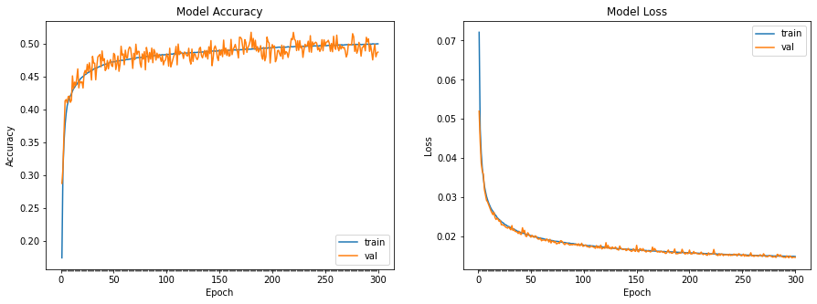

```python
plot_model_history(regenrative_gru)
```

```python
# First 8 patches for digit '6'
x_1 = x_test1[y_test == 6]
x_11 = x_1[0:1:,0:8,:]
x_11.shape
```

```
(1, 8, 49)
```

```python
for i in range(8,16,1):
  print(f"predicting {i+1}-th frame")
  if i == 8:
    updated_x = np.concatenate((x_11, model.predict(x_11)[:,np.newaxis, -1,:]), axis=1)
  else:
    updated_x = np.concatenate((updated_x, model.predict(updated_x)[:,np.newaxis, -1,:]), axis=1)
# predicted_dict[i]
updated_x.shape
```

```
predicting 9-th frame
predicting 10-th frame
predicting 11-th frame
predicting 12-th frame
predicting 13-th frame
predicting 14-th frame
predicting 15-th frame
predicting 16-th frame
```

```
(1, 16, 49)
```

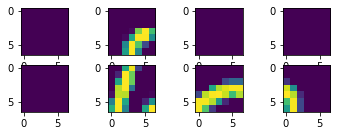

```python
# Plot first 8 patches for digit '6'
for col in range(8):
  plt.subplot(4, 4, col+1)
  plt.imshow(x_11[0][col].reshape(7,7))
```

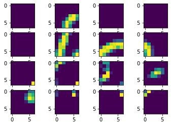

```python
# Plot first trained and predicted patches for digit '6'
for col in range(16):
  plt.subplot(4, 4, col+1)
  plt.imshow(updated_x[0][col].reshape(7,7))
```

```python
l1 = [0,1,2,3,4,5,6,7,8,9,10,11,12,13,14,15]
a1 =[]
for i in l1:
  t = updated_x[:,i,:].reshape(7,7)
  a1.append(t)
a2=np.array(a1)
a2.shape
```

```
(16, 7, 7)
```

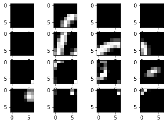

```python
#Plot 16 patches each of 7 x 7
for col in range(16):
  plt.subplot(4, 4, col+1)
  plt.imshow(a2[col],cmap='gray')
```

Align all 7x7 patches to form a 28 x 28 image

```python
args = (a2[0], a2[1], a2[2],a2[3])
xt0 = np.concatenate(args,axis=1)
x0t0 = xt0.reshape(-1,28)

args1 = (a2[4], a2[5], a2[6],a2[7])
xt1 = np.concatenate(args1,axis=1)
x1t1 = xt1.reshape(-1,28)

args2 = (a2[8], a2[9], a2[10],a2[11])
xt2 = np.concatenate(args2,axis=1)
x2t2 = xt2.reshape(-1,28)

args3 = (a2[12], a2[13], a2[14],a2[15])
xt3 = np.concatenate(args3,axis=1)
x3t3 = xt3.reshape(-1,28)

list1 = (x0t0,x1t1,x2t2,x3t3)
final = np.concatenate(list1,axis=0)
final.shape
```

```
(28, 28)
```

```python
final1 = final.reshape(-1,28,28)
final1.shape
```

```
(1, 28, 28)
```

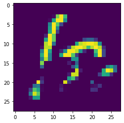

```python
#Plot the image - 28 x 28
plt.imshow(final,vmin=0, vmax=1)
```

Plot the 10 chosen images from the same digits in this case - digit '6'

**Digit '6'** Take 10 images from test data having their digit class as '6'. These are the original images

```
Shape of X_6 (10, 28, 28)
```

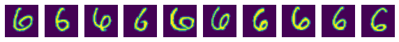

```python
# Take 10 images from test data having their digit class as '6'
X_6 = x_test[y_test == 6][:10]
print("Shape of X_6",X_6.shape)

#Plot the test data
fig, axs = plt.subplots(1,10,sharex=True , figsize=(10,10))
for j in range(10):
  axs[j].imshow(X_6[j])
  axs[j].axis('off')
```

```python
# First 8 patches for digit '6' for 10 test samples
d_6 = x_test1[y_test == 6][:10]
d_66 = d_6[:10:,0:8,:]
d_66.shape
```

```
(10, 8, 49)
```

```python
for i in range(8,16,1):
  print(f"predicting {i+1}-th frame")
  if i == 8:
    updated_6_n = np.concatenate((d_66, model.predict(d_66)[:,np.newaxis, -1,:]), axis=1)
  else:
    updated_6_n = np.concatenate((updated_6_n, model.predict(updated_6_n)[:,np.newaxis, -1,:]), axis=1)
# predicted_dict[i]
updated_6_n.shape
```

```
predicting 9-th frame
predicting 10-th frame
predicting 11-th frame
predicting 12-th frame
predicting 13-th frame
predicting 14-th frame
predicting 15-th frame
predicting 16-th frame
```

```
(10, 16, 49)
```

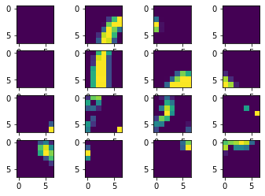

```python
for col in range(16):
  plt.subplot(4, 4, col+1)
  plt.imshow(updated_6_n[7][col].reshape(7,7))
```

```python
l6_1 = [0,1,2,3,4,5,6,7,8,9,10,11,12,13,14,15]
a6_1 =[]
for i in l6_1:
    b6_1 = updated_6_n[0,i,:].reshape(7,7)
    a6_1.append(b6_1)
c6_1=np.array(a6_1)

t6_1 = (c6_1[0], c6_1[1],c6_1[2],c6_1[3])
ct6_1 = np.concatenate(t6_1,axis=1)
r6_1 = ct6_1.reshape(-1,28)

t61_1 = (c6_1[4], c6_1[5],c6_1[6],c6_1[7])
ct61_1 = np.concatenate(t61_1,axis=1)
r61_1 = ct61_1.reshape(-1,28)

t62_1 = (c6_1[8], c6_1[9], c6_1[10],c6_1[11])
ct62_1 = np.concatenate(t62_1,axis=1)
r62_1 = ct62_1.reshape(-1,28)

t63_1 = (c6_1[12], c6_1[13], c6_1[14],c6_1[15])
ct63_1 = np.concatenate(t63_1,axis=1)
r63_1 = ct63_1.reshape(-1,28)

m6_1 = (ct6_1,ct61_1,ct62_1,ct63_1)
final_6_1 = np.concatenate(m6_1,axis=0)
final66_1 = final_6_1.reshape(-1,28,28)

####################################################
l6_2 = [0,1,2,3,4,5,6,7,8,9,10,11,12,13,14,15]
a6_2 =[]
for i in l6_2:
    b6_2 = updated_6_n[1,i,:].reshape(7,7)
    a6_2.append(b6_2)
c6_2=np.array(a6_2)

t6_2 = (c6_2[0], c6_2[1], c6_2[2],c6_2[3])
ct6_2 = np.concatenate(t6_2,axis=1)
r6_2 = ct6_2.reshape(-1,28)

t61_2 = (c6_2[4], c6_2[5],c6_2[6],c6_2[7])
ct61_2 = np.concatenate(t61_2,axis=1)
r61_2 = ct61_2.reshape(-1,28)

t62_2 = (c6_2[8], c6_2[9], c6_2[10],c6_2[11])
ct62_2 = np.concatenate(t62_2,axis=1)
r62_2 = ct62_2.reshape(-1,28)

t63_2 = (c6_2[12], c6_2[13], c6_2[14],c6_2[15])
ct63_2 = np.concatenate(t63_2,axis=1)
r63_2 = ct63_2.reshape(-1,28)

m6_2 = (ct6_2,ct61_2,ct62_2,ct63_2)
final_6_2 = np.concatenate(m6_2,axis=0)

final66_2 = final_6_2.reshape(-1,28,28)

############################################
l6_3 = [0,1,2,3,4,5,6,7,8,9,10,11,12,13,14,15]
a6_3 =[]
for i in l6_3:
    b6_3 = updated_6_n[2,i,:].reshape(7,7)
    a6_3.append(b6_3)
c6_3=np.array(a6_3)

t6_3 = (c6_3[0], c6_3[1], c6_3[2],c6_3[3])
ct6_3 = np.concatenate(t6_3,axis=1)
r6_3 = ct6_3.reshape(-1,28)

t61_3 = (c6_3[4], c6_3[5],c6_3[6],c6_3[7])
ct61_3 = np.concatenate(t61_3,axis=1)
r61_3 = ct61_3.reshape(-1,28)

t62_3 = (c6_3[8], c6_3[9], c6_3[10],c6_3[11])
ct62_3 = np.concatenate(t62_3,axis=1)
r62_3 = ct62_3.reshape(-1,28)

t63_3 = (c6_3[12], c6_3[13], c6_3[14],c6_3[15])
ct63_3 = np.concatenate(t63_3,axis=1)
r63_3 = ct63_3.reshape(-1,28)

m6_3 = (ct6_3,ct61_3,ct62_3,ct63_3)
final_6_3 = np.concatenate(m6_3,axis=0)

final66_3 = final_6_3.reshape(-1,28,28)
################################################
l6_4 = [0,1,2,3,4,5,6,7,8,9,10,11,12,13,14,15]
a6_4 =[]
for i in l6_4:
    b6_4 = updated_6_n[3,i,:].reshape(7,7)
    a6_4.append(b6_4)
c6_4=np.array(a6_4)

t6_4 = (c6_4[0], c6_4[1], c6_4[2],c6_4[3])
ct6_4 = np.concatenate(t6_4,axis=1)
r6_4 = ct6_4.reshape(-1,28)

t61_4 = (c6_4[4],c6_4[5],c6_4[6],c6_4[7])
ct61_4 = np.concatenate(t61_4,axis=1)
r61_4 = ct61_4.reshape(-1,28)

t62_4 = (c6_4[8], c6_4[9], c6_4[10],c6_4[11])
ct62_4 = np.concatenate(t62_4,axis=1)
r62_4 = ct62_4.reshape(-1,28)

t63_4 = (c6_4[12], c6_4[13],c6_4[14],c6_4[15])
ct63_4 = np.concatenate(t63_4,axis=1)
r63_4 = ct63_4.reshape(-1,28)

m6_4 = (ct6_4,ct61_4,ct62_4,ct63_4)
final_6_4 = np.concatenate(m6_4,axis=0)

final66_4 = final_6_4.reshape(-1,28,28)
##################################################

l6_5 = [0,1,2,3,4,5,6,7,8,9,10,11,12,13,14,15]
a6_5 =[]
for i in l6_5:
    b6_5 = updated_6_n[4,i,:].reshape(7,7)
    a6_5.append(b6_5)
c6_5=np.array(a6_5)

t6_5 = (c6_5[0], c6_5[1], c6_5[2],c6_5[3])
ct6_5 = np.concatenate(t6_5,axis=1)
r6_5 = ct6_5.reshape(-1,28)

t61_5 = (c6_5[4],c6_5[5],c6_5[6],c6_5[7])
ct61_5 = np.concatenate(t61_5,axis=1)
r61_5 = ct61_5.reshape(-1,28)

t62_5 = (c6_5[8], c6_5[9],c6_5[10],c6_5[11])
ct62_5 = np.concatenate(t62_5,axis=1)
r62_5 = ct62_5.reshape(-1,28)

t63_5 = (c6_5[12], c6_5[13],c6_5[14],c6_5[15])
ct63_5 = np.concatenate(t63_5,axis=1)
r63_5 = ct63_5.reshape(-1,28)

m6_5 = (ct6_5,ct61_5,ct62_5,ct63_5)
final_6_5 = np.concatenate(m6_5,axis=0)

final66_5 = final_6_5.reshape(-1,28,28)

#################################################

l6_6 = [0,1,2,3,4,5,6,7,8,9,10,11,12,13,14,15]
a6_6 =[]
for i in l6_6:
    b6_6 = updated_6_n[6,i,:].reshape(7,7)
    a6_6.append(b6_6)
c6_6=np.array(a6_6)

t6_6 = (c6_6[0], c6_6[1], c6_6[2],c6_6[3])
ct6_6 = np.concatenate(t6_6,axis=1)
r6_6 = ct6_6.reshape(-1,28)

t61_6 = (c6_6[4],c6_6[5],c6_6[6],c6_6[7])
ct61_6 = np.concatenate(t61_6,axis=1)
r61_6 = ct61_6.reshape(-1,28)

t62_6 = (c6_6[8], c6_6[9], c6_6[10],c6_6[11])
ct62_6 = np.concatenate(t62_6,axis=1)
r62_6 = ct62_6.reshape(-1,28)

t63_6 = (c6_6[12], c6_6[13],c6_6[14],c6_6[15])
ct63_6 = np.concatenate(t63_6,axis=1)
r63_6 = ct63_6.reshape(-1,28)

m6_6 = (ct6_6,ct61_6,ct62_6,ct63_6)
final_6_6 = np.concatenate(m6_6,axis=0)

final66_6 = final_6_6.reshape(-1,28,28)

#####################################################
l6_7 = [0,1,2,3,4,5,6,7,8,9,10,11,12,13,14,15]
a6_7 =[]
for i in l6_7:
    b6_7 = updated_6_n[6,i,:].reshape(7,7)
    a6_7.append(b6_7)
c6_7=np.array(a6_7)

t6_7 = (c6_7[0], c6_7[1], c6_7[2],c6_7[3])
ct6_7 = np.concatenate(t6_7,axis=1)
r6_7 = ct6_7.reshape(-1,28)

t61_7 = (c6_7[4],c6_7[5],c6_7[6],c6_7[7])
ct61_7 = np.concatenate(t61_7,axis=1)
r61_7 = ct61_7.reshape(-1,28)

t62_7 = (c6_7[8], c6_7[9],c6_7[10],c6_7[11])
ct62_7 = np.concatenate(t62_7,axis=1)
r62_7 = ct62_7.reshape(-1,28)

t63_7 = (c6_7[12], c6_7[13],c6_7[14],c6_7[15])
ct63_7 = np.concatenate(t63_7,axis=1)
r63_7 = ct63_7.reshape(-1,28)

m6_7 = (ct6_7,ct61_7,ct62_7,ct63_7)
final_6_7 = np.concatenate(m6_7,axis=0)

final66_7 = final_6_7.reshape(-1,28,28)

##################################################
l6_8 = [0,1,2,3,4,5,6,7,8,9,10,11,12,13,14,15]
a6_8 =[]
for i in l6_8:
    b6_8 = updated_6_n[7,i,:].reshape(7,7)
    a6_8.append(b6_8)
c6_8=np.array(a6_8)

t6_8 = (c6_8[0], c6_8[1], c6_8[2],c6_8[3])
ct6_8 = np.concatenate(t6_8,axis=1)
r6_8 = ct6_8.reshape(-1,28)

t61_8 = (c6_8[4],c6_8[5],c6_8[6],c6_8[7])
ct61_8 = np.concatenate(t61_8,axis=1)
r61_8 = ct61_8.reshape(-1,28)

t62_8 = (c6_8[8], c6_8[9], c6_8[10],c6_8[11])
ct62_8 = np.concatenate(t62_8,axis=1)
r62_8 = ct62_8.reshape(-1,28)

t63_8 = (c6_8[12], c6_8[13],c6_8[14],c6_8[15])
ct63_8 = np.concatenate(t63_8,axis=1)
r63_8 = ct63_8.reshape(-1,28)

m6_8 = (ct6_8,ct61_8,ct62_8,ct63_8)
final_6_8 = np.concatenate(m6_8,axis=0)

final66_8 = final_6_8.reshape(-1,28,28)

##############################################################

l6_9 = [0,1,2,3,4,5,6,7,8,9,10,11,12,13,14,15]
a6_9 =[]
for i in l6_9:
    b6_9 = updated_6_n[8,i,:].reshape(7,7)
    a6_9.append(b6_9)
c6_9=np.array(a6_9)

t6_9 = (c6_9[0], c6_9[1], c6_9[2],c6_9[3])
ct6_9 = np.concatenate(t6_9,axis=1)
r6_9 = ct6_9.reshape(-1,28)

t61_9 = (c6_9[4],c6_9[5],c6_9[6],c6_9[7])
ct61_9 = np.concatenate(t61_9,axis=1)
r61_9 = ct61_9.reshape(-1,28)

t62_9 = (c6_9[8],c6_9[9], c6_9[10],c6_9[11])
ct62_9 = np.concatenate(t62_9,axis=1)
r62_9 = ct62_9.reshape(-1,28)

t63_9 = (c6_9[12], c6_9[13],c6_9[14],c6_9[15])
ct63_9 = np.concatenate(t63_9,axis=1)
r63_9 = ct63_9.reshape(-1,28)

m6_9 = (ct6_9,ct61_9,ct62_9,ct63_9)
final_6_9 = np.concatenate(m6_9,axis=0)

final66_9 = final_6_9.reshape(-1,28,28)

###############################################
l6_a = [0,1,2,3,4,5,6,7,8,9,10,11,12,13,14,15]
a6_a =[]
for i in l6_a:
    b6_a = updated_6_n[9,i,:].reshape(7,7)
    a6_a.append(b6_a)
c6_a=np.array(a6_a)

t6_a = (c6_a[0], c6_a[1], c6_a[2],c6_a[3])
ct6_a = np.concatenate(t6_a,axis=1)
r6_a = ct6_a.reshape(-1,28)

t61_a = (c6_a[4],c6_a[5],c6_a[6],c6_a[7])
ct61_a = np.concatenate(t61_a,axis=1)
r61_a = ct61_a.reshape(-1,28)

t62_a = (c6_a[8], c6_a[9], c6_a[10],c6_a[11])
ct62_a = np.concatenate(t62_a,axis=1)
r62_a = ct62_a.reshape(-1,28)

t63_a = (c6_a[12], c6_a[13],c6_a[14],c6_a[15])
ct63_a = np.concatenate(t63_a,axis=1)
r63_a = ct63_a.reshape(-1,28)

m6_a = (ct6_a,ct61_a,ct62_a,ct63_a)
final_6_a = np.concatenate(m6_a,axis=0)

final66_a = final_6_a.reshape(-1,28,28)
```

```python
#x_0 = (final_0_1,final_01,final_0_2,final_0_3,final_0_4,final_0_5,final_0_6,final_0_7,final_0_8,final_0_9)
x_6= (final66_1,final66_2,final66_3,final66_4,final66_5,final66_6,final66_7,final66_8,final66_9,final66_a)
x_6_f = np.concatenate(x_6,axis=0)
x_6_f.shape
```

```
(10, 28, 28)
```

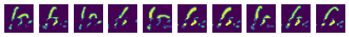

```python
D = {0,1,2,3,4,5,6,7,8,9}
#Plot the test data
fig, axs = plt.subplots(1,10,sharex=True , figsize=(10,10))
for j in D:
  axs[j].imshow(x_6_f[j],vmin=0, vmax=1)
  axs[j].axis('off')
```

Method 1 : Collect all the 100 images and run the prediction for the last 8 patches. To resize the predicted image into 28 x 28 I tried to use combination of numpy concatenate and lists.

```python
# Collect all the images - 10 images for each of the 10 digit class
tt = x_test1[y_test==0][:10]
tt1 = x_test1[y_test==1][:10]
tt2 = x_test1[y_test==2][:10]
tt3 = x_test1[y_test==3][:10]
tt4 = x_test1[y_test==4][:10]
tt5 = x_test1[y_test==5][:10]
tt6 = x_test1[y_test==6][:10]
tt7 = x_test1[y_test==7][:10]
tt8 = x_test1[y_test==8][:10]
tt9 = x_test1[y_test==9][:10]
```

```python
ll = [tt,tt1,tt2,tt3,tt4,tt5,tt6,tt7,tt8,tt9]
l = np.concatenate(ll,axis=0)
l.shape
```

```
(100, 16, 49)
```

```python
# First 8 patches for the 100 test samples
d = l[:,0:8,:]
d.shape
```

```
(100, 8, 49)
```

```python
for i in range(8,16,1):
  print(f"predicting {i+1}-th frame")
  if i == 8:
    updated = np.concatenate((d, model.predict(d)[:,np.newaxis, -1,:]), axis=1)
  else:
    updated = np.concatenate((updated, model.predict(updated)[:,np.newaxis, -1,:]), axis=1)
# predicted_dict[i]
updated.shape
```

```
predicting 9-th frame
predicting 10-th frame
predicting 11-th frame
predicting 12-th frame
predicting 13-th frame
predicting 14-th frame
predicting 15-th frame
predicting 16-th frame
```

```
(100, 16, 49)
```

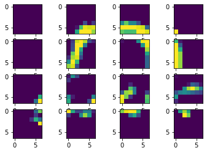

```python
for col in range(16):
  plt.subplot(4, 4, col+1)
  plt.imshow(updated[1][col].reshape(7,7))
```

```python
# Method1 to plot a resized image 28x28
p1 = updated[0,0,:].reshape(7,7)
p2 = updated[0,1,:].reshape(7,7)
p3 = updated[0,2,:].reshape(7,7)
p4 = updated[0,3,:].reshape(7,7)
patch1 = (p1,p2,p3,p4)
con1 = np.concatenate(patch1,axis=1)
con11 = con1.reshape(-1,28)
p5 = updated[0,4,:].reshape(7,7)
p6 = updated[0,5,:].reshape(7,7)
p7 = updated[0,6,:].reshape(7,7)
p8 = updated[0,7,:].reshape(7,7)
patch2 = (p5,p6,p7,p8)
con2 = np.concatenate(patch2,axis=1)
con21 = con2.reshape(-1,28)
p9 = updated[0,8,:].reshape(7,7)
p10 = updated[0,9,:].reshape(7,7)
p11 = updated[0,10,:].reshape(7,7)
p12 = updated[0,11,:].reshape(7,7)
patch3 = (p9,p10,p11,p12)
con3 = np.concatenate(patch3,axis=1)
con31 = con3.reshape(-1,28)
p13 = updated[0,12,:].reshape(7,7)
p14 = updated[0,13,:].reshape(7,7)
p15 = updated[0,14,:].reshape(7,7)
p16 = updated[0,15,:].reshape(7,7)
patch4 = (p13,p14,p15,p16)
con4 = np.concatenate(patch4,axis=1)
con41 = con4.reshape(-1,28)
concat = (con11,con21,con31,con41)
f1 = np.concatenate(concat,axis=0)
f11 = f1.reshape(-1,28,28)
f11.shape
```

```
(1, 28, 28)
```

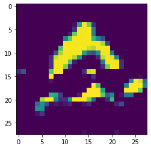

```python
plt.imshow(f11[0],vmin=0,vmax=1)
```

Method 2 : This method has more number of steps and step by step understanding of the image restruction from the non overlapping patches can be seen.

Digit '0' Take 10 images from test data having their digit class as '0'. These are the original images

```
Shape of X_O (10, 28, 28)
```

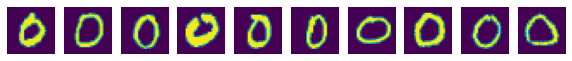

```python
# Take 10 images from test data having their digit class as '0'
X_0 = x_test[y_test == 0][:10]
print("Shape of X_O",X_0.shape)

#Plot the test data
fig, axs = plt.subplots(1,10,sharex=True , figsize=(10,10))
for j in range(10):
  axs[j].imshow(X_0[j])
  axs[j].axis('off')
```

```python
# First 8 patches for digit '0' for 10 test samples
d_0 = x_test1[y_test == 0][:10]
d_00 = d_0[:10:,0:8,:]
d_00.shape
```

```
(10, 8, 49)
```

```python
#predicting the {i+1}-th frame

for i in range(8,16,1):
  print(f"predicting {i+1}-th frame")
  if i == 8:
    updated_0_n = np.concatenate((d_00, model.predict(d_00)[:,np.newaxis, -1,:]), axis=1)
  else:
    updated_0_n = np.concatenate((updated_0_n, model.predict(updated_0_n)[:,np.newaxis, -1,:]), axis=1)
# predicted_dict[i]
updated_0_n.shape
```

```
predicting 9-th frame
predicting 10-th frame
predicting 11-th frame
predicting 12-th frame
predicting 13-th frame
predicting 14-th frame
predicting 15-th frame
predicting 16-th frame
```

```
(10, 16, 49)
```

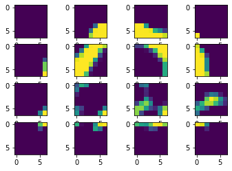

```python
#plot one sample image
for col in range(16):
  plt.subplot(4, 4, col+1)
  plt.imshow(updated_0_n[7][col].reshape(7,7))
```

```python
l0 = [0,1,2,3,4,5,6,7,8,9,10,11,12,13,14,15]
a0 =[]
for i in l0:
    b0 = updated_0_n[0,i,:].reshape(7,7)
    a0.append(b0)
c0=np.array(a0)

t0 = (c0[0], c0[1], c0[2],c0[3])
ct0 = np.concatenate(t0,axis=1)
r0 = ct0.reshape(-1,28)

t01 = (c0[4], c0[5], c0[6],c0[7])
ct01 = np.concatenate(t01,axis=1)
r01 = ct01.reshape(-1,28)

t02 = (c0[8], c0[9], c0[10],c0[11])
ct02 = np.concatenate(t02,axis=1)
r02 = ct02.reshape(-1,28)

t03 = (c0[12], c0[13], c0[14],c0[15])
ct03 = np.concatenate(t03,axis=1)
r03 = ct03.reshape(-1,28)

m0 = (ct0,ct01,ct02,ct03)
final_0_1 = np.concatenate(m0,axis=0)
final0 = final_0_1.reshape(-1,28,28)

################################################
l_1 = [0,1,2,3,4,5,6,7,8,9,10,11,12,13,14,15]
a_1 =[]
for i in l_1:
    b1 = updated_0_n[1,i,:].reshape(7,7)
    a_1.append(b1)
c1=np.array(a_1)

t1 = (c1[0], c1[1], c1[2],c1[3])
ct1 = np.concatenate(t1,axis=1)
r1 = ct1.reshape(-1,28)

t011 = (c1[4], c1[5], c1[6],c1[7])
ct011 = np.concatenate(t011,axis=1)
r011 = ct011.reshape(-1,28)

t021 = (c1[8], c1[9], c1[10],c1[11])
ct021 = np.concatenate(t021,axis=1)
r021 = ct021.reshape(-1,28)

t031 = (c1[12], c1[13], c1[14],c1[15])
ct031 = np.concatenate(t031,axis=1)
r031 = ct031.reshape(-1,28)

m1 = (ct1,ct011,ct021,ct031)
final_01 = np.concatenate(m1,axis=0)
final_1 = final_01.reshape(-1,28,28)

######################################################
l2 = [0,1,2,3,4,5,6,7,8,9,10,11,12,13,14,15]
a2 =[]
for i in l2:
    b2 = updated_0_n[2,i,:].reshape(7,7)
    a2.append(b2)
c2=np.array(a2)

t2 = (c2[0], c2[1], c2[2],c2[3])
ct2 = np.concatenate(t2,axis=1)
r2 = ct2.reshape(-1,28)

t012 = (c2[4], c2[5], c2[6],c2[7])
ct012 = np.concatenate(t012,axis=1)
r012 = ct012.reshape(-1,28)

t022 = (c2[8], c2[9], c2[10],c2[11])
ct022 = np.concatenate(t022,axis=1)
r022 = ct022.reshape(-1,28)

t032 = (c2[12], c2[13], c2[14],c2[15])
ct032 = np.concatenate(t032,axis=1)
r032 = ct032.reshape(-1,28)

m2 = (ct2,ct012,ct022,ct032)
final_0_2 = np.concatenate(m2,axis=0)
final2 = final_0_2.reshape(-1,28,28)

################################################
l3 = [0,1,2,3,4,5,6,7,8,9,10,11,12,13,14,15]
a3 =[]
for i in l3:
    b3 = updated_0_n[3,i,:].reshape(7,7)
    a3.append(b3)
c3=np.array(a3)

t3 = (c3[0], c3[1], c3[2],c3[3])
ct3 = np.concatenate(t3,axis=1)
r3 = ct3.reshape(-1,28)

t013 = (c3[4], c3[5], c3[6],c3[7])
ct013 = np.concatenate(t013,axis=1)
r013 = ct013.reshape(-1,28)

t023 = (c3[8], c3[9], c3[10],c3[11])
ct023 = np.concatenate(t023,axis=1)
r023 = ct023.reshape(-1,28)

t033 = (c3[12], c3[13], c3[14],c3[15])
ct033 = np.concatenate(t033,axis=1)
r033 = ct033.reshape(-1,28)

m3 = (ct3,ct013,ct023,ct033)
final_0_3 = np.concatenate(m3,axis=0)
final3 = final_0_3.reshape(-1,28,28)

##########################################
l4 = [0,1,2,3,4,5,6,7,8,9,10,11,12,13,14,15]
a4 =[]
for i in l4:
    b4 = updated_0_n[4,i,:].reshape(7,7)
    a4.append(b4)
c4=np.array(a4)

t4 = (c4[0], c4[1], c4[2],c4[3])
ct4 = np.concatenate(t4,axis=1)
r4 = ct4.reshape(-1,28)

t014 = (c4[4], c4[5], c4[6],c4[7])
ct014 = np.concatenate(t014,axis=1)
r014 = ct014.reshape(-1,28)

t024 = (c4[8], c4[9], c4[10],c4[11])
ct024 = np.concatenate(t024,axis=1)
r024 = ct024.reshape(-1,28)

t034 = (c4[12], c4[13], c4[14],c4[15])
ct034 = np.concatenate(t034,axis=1)
r034 = ct034.reshape(-1,28)

m4 = (ct4,ct014,ct024,ct034)
final_0_4 = np.concatenate(m4,axis=0)
final4 = final_0_4.reshape(-1,28,28)

##############################################
l5 = [0,1,2,3,4,5,6,7,8,9,10,11,12,13,14,15]
a5 =[]
for i in l5:
    b5 = updated_0_n[5,i,:].reshape(7,7)
    a5.append(b5)
c5=np.array(a5)

t5 = (c5[0], c5[1], c5[2],c5[3])
ct5 = np.concatenate(t5,axis=1)
r5 = ct5.reshape(-1,28)

t015 = (c5[4], c5[5], c5[6],c5[7])
ct015 = np.concatenate(t015,axis=1)
r015 = ct015.reshape(-1,28)

t025 = (c5[8], c5[9], c5[10],c5[11])
ct025 = np.concatenate(t025,axis=1)
r025 = ct025.reshape(-1,28)

t035 = (c5[12], c5[13], c5[14],c5[15])
ct035 = np.concatenate(t035,axis=1)
r035 = ct035.reshape(-1,28)

m5 = (ct5,ct015,ct025,ct035)
final_0_5 = np.concatenate(m5,axis=0)
final5 = final_0_5.reshape(-1,28,28)

###############################################
l6 = [0,1,2,3,4,5,6,7,8,9,10,11,12,13,14,15]
a6 =[]
for i in l6:
    b6 = updated_0_n[6,i,:].reshape(7,7)
    a6.append(b6)
c6=np.array(a6)

t6 = (c6[0], c6[1], c6[2],c6[3])
ct6 = np.concatenate(t6,axis=1)
r6 = ct6.reshape(-1,28)

t016 = (c6[4], c6[5], c6[6],c6[7])
ct016 = np.concatenate(t016,axis=1)
r016 = ct016.reshape(-1,28)

t026 = (c6[8], c6[9], c6[10],c6[11])
ct026 = np.concatenate(t026,axis=1)
r026 = ct026.reshape(-1,28)

t036 = (c6[12], c6[13], c6[14],c6[15])
ct036 = np.concatenate(t036,axis=1)
r036 = ct036.reshape(-1,28)

m6 = (ct6,ct016,ct026,ct036)
final_0_6 = np.concatenate(m6,axis=0)
final6 = final_0_6.reshape(-1,28,28)

###################################################
l7 = [0,1,2,3,4,5,6,7,8,9,10,11,12,13,14,15]
a7 =[]
for i in l7:
    b7 = updated_0_n[7,i,:].reshape(7,7)
    a7.append(b7)
c7=np.array(a7)

t7 = (c7[0], c7[1], c7[2],c7[3])
ct7 = np.concatenate(t7,axis=1)
r7 = ct7.reshape(-1,28)

t017 = (c7[4], c7[5], c7[6],c7[7])
ct017 = np.concatenate(t017,axis=1)
r017 = ct017.reshape(-1,28)

t027 = (c7[8], c7[9], c7[10],c7[11])
ct027 = np.concatenate(t027,axis=1)
r027 = ct027.reshape(-1,28)

t037 = (c7[12], c7[13], c7[14],c7[15])
ct037 = np.concatenate(t037,axis=1)
r037 = ct037.reshape(-1,28)

m7 = (ct7,ct017,ct027,ct037)
final_0_7 = np.concatenate(m7,axis=0)
final7 = final_0_7.reshape(-1,28,28)

###################################################
l8 = [0,1,2,3,4,5,6,7,8,9,10,11,12,13,14,15]
a8 =[]
for i in l8:
    b8 = updated_0_n[8,i,:].reshape(7,7)
    a8.append(b8)
c8=np.array(a8)

t8 = (c8[0], c8[1], c8[2],c8[3])
ct8 = np.concatenate(t8,axis=1)
r8 = ct8.reshape(-1,28)

t018 = (c8[4], c8[5], c8[6],c8[7])
ct018 = np.concatenate(t018,axis=1)
r018 = ct018.reshape(-1,28)

t028 = (c8[8], c8[9], c8[10],c8[11])
ct028 = np.concatenate(t028,axis=1)
r028 = ct028.reshape(-1,28)

t038 = (c8[12], c8[13], c8[14],c8[15])
ct038 = np.concatenate(t038,axis=1)
r038 = ct038.reshape(-1,28)

m8 = (ct8,ct018,ct028,ct038)
final_0_8 = np.concatenate(m8,axis=0)
final8 = final_0_8.reshape(-1,28,28)

####################################################
l9 = [0,1,2,3,4,5,6,7,8,9,10,11,12,13,14,15]
a9 =[]
for i in l9:
    b9 = updated_0_n[9,i,:].reshape(7,7)
    a9.append(b9)
c9=np.array(a9)

t9 = (c9[0], c9[1], c9[2],c9[3])
ct9= np.concatenate(t9,axis=1)
r9 = ct9.reshape(-1,28)

t019 = (c9[4], c9[5], c9[6],c9[7])
ct019 = np.concatenate(t019,axis=1)
r019 = ct019.reshape(-1,28)

t029 = (c9[8], c9[9], c9[10],c9[11])
ct029 = np.concatenate(t029,axis=1)
r029 = ct029.reshape(-1,28)

t039 = (c9[12], c9[13], c9[14],c9[15])
ct039 = np.concatenate(t039,axis=1)
r039 = ct039.reshape(-1,28)

m9 = (ct9,ct019,ct029,ct039)
final_0_9 = np.concatenate(m9,axis=0)

final9 = final_0_9.reshape(-1,28,28)

#############################################
```

```python
#x_0 = (final_0_1,final_01,final_0_2,final_0_3,final_0_4,final_0_5,final_0_6,final_0_7,final_0_8,final_0_9)
x_0 = (final0,final_1,final2,final3,final4,final5,final6,final7,final8,final9)
x_0_f = np.concatenate(x_0,axis=0)
x_0_f.shape
```

```
(10, 28, 28)
```

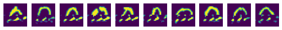

```python
D = {0,1,2,3,4,5,6,7,8,9}
#Plot the test data
fig, axs = plt.subplots(1,10,sharex=True , figsize=(10,10))
for j in D:
  axs[j].imshow(x_0_f[j],vmin=0, vmax=1)
  axs[j].axis('off')
```

Digit '1' Take 10 images from test data having their digit class as '1'. These are the original images

```
Shape of X_1 (10, 28, 28)
```

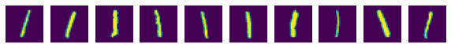

```python
# Take 10 images from test data having their digit class as '1'
X_1 = x_test[y_test == 1][:10]
print("Shape of X_1",X_1.shape)

#Plot the test data
fig, axs = plt.subplots(1,10,sharex=True , figsize=(10,10))
for j in range(10):
  axs[j].imshow(X_1[j])
  axs[j].axis('off')
```

```python
# First 8 patches for digit '1' for 10 test samples
d_1 = x_test1[y_test == 1][:10]
d_11 = d_1[:10:,0:8,:]
d_11.shape
```

```
(10, 8, 49)
```

```python
for i in range(8,16,1):
  print(f"predicting {i+1}-th frame")
  if i == 8:
    updated_1_n = np.concatenate((d_11, model.predict(d_11)[:,np.newaxis, -1,:]), axis=1)
  else:
    updated_1_n = np.concatenate((updated_1_n, model.predict(updated_1_n)[:,np.newaxis, -1,:]), axis=1)
# predicted_dict[i]
updated_1_n.shape
```

```
predicting 9-th frame
predicting 10-th frame
predicting 11-th frame
predicting 12-th frame
predicting 13-th frame
predicting 14-th frame
predicting 15-th frame
predicting 16-th frame
```

```
(10, 16, 49)
```

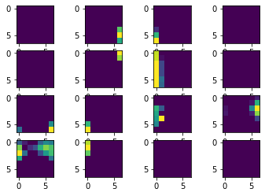

```python
for col in range(16):
  plt.subplot(4, 4, col+1)
  plt.imshow(updated_1_n[7][col].reshape(7,7))
```

```python
l1_1 = [0,1,2,3,4,5,6,7,8,9,10,11,12,13,14,15]
a1_1 =[]
for i in l1_1:
    b1_1 = updated_1_n[0,i,:].reshape(7,7)
    a1_1.append(b1_1)
c1_1=np.array(a1_1)

t1_1 = (c1_1[0], c1_1[1], c1_1[2],c1_1[3])
ct1_1 = np.concatenate(t1_1,axis=1)
r1_1 = ct1_1.reshape(-1,28)

t11_1 = (c1_1[4], c1_1[5],c1_1[6],c1_1[7])
ct11_1 = np.concatenate(t11_1,axis=1)
r11_1 = ct11_1.reshape(-1,28)

t12_1 = (c1_1[8], c1_1[9], c1_1[10],c1_1[11])
ct12_1 = np.concatenate(t12_1,axis=1)
r12_1 = ct12_1.reshape(-1,28)

t13_1 = (c1_1[12], c1_1[13], c1_1[14],c1_1[15])
ct13_1 = np.concatenate(t13_1,axis=1)
r13_1 = ct13_1.reshape(-1,28)

m1_1 = (ct1_1,ct11_1,ct12_1,ct13_1)
final_1_1 = np.concatenate(m1_1,axis=0)
final11_1 = final_1_1.reshape(-1,28,28)

#######################################################

l1_2 = [0,1,2,3,4,5,6,7,8,9,10,11,12,13,14,15]
a1_2 =[]
for i in l1_2:
    b1_2 = updated_1_n[1,i,:].reshape(7,7)
    a1_2.append(b1_2)
c1_2=np.array(a1_2)

t1_2 = (c1_2[0], c1_2[1], c1_2[2],c1_2[3])
ct1_2 = np.concatenate(t1_2,axis=1)
r1_2 = ct1_2.reshape(-1,28)

t11_2 = (c1_2[4], c1_2[5],c1_2[6],c1_2[7])
ct11_2 = np.concatenate(t11_2,axis=1)
r11_2 = ct11_2.reshape(-1,28)

t12_2 = (c1_2[8], c1_2[9], c1_2[10],c1_2[11])
ct12_2 = np.concatenate(t12_2,axis=1)
r12_2 = ct12_2.reshape(-1,28)

t13_2 = (c1_2[12], c1_2[13], c1_2[14],c1_2[15])
ct13_2 = np.concatenate(t13_2,axis=1)
r13_2 = ct13_2.reshape(-1,28)

m1_2 = (ct1_2,ct11_2,ct12_2,ct13_2)
final_1_2 = np.concatenate(m1_2,axis=0)
final11_2 = final_1_2.reshape(-1,28,28)

########################################################
l1_3 = [0,1,2,3,4,5,6,7,8,9,10,11,12,13,14,15]
a1_3 =[]
for i in l1_3:
    b1_3 = updated_1_n[2,i,:].reshape(7,7)
    a1_3.append(b1_3)
c1_3=np.array(a1_3)

t1_3 = (c1_3[0], c1_3[1], c1_3[2],c1_3[3])
ct1_3 = np.concatenate(t1_3,axis=1)
r1_3 = ct1_3.reshape(-1,28)

t11_3 = (c1_3[4], c1_3[5],c1_3[6],c1_3[7])
ct11_3 = np.concatenate(t11_3,axis=1)
r11_3 = ct11_3.reshape(-1,28)

t12_3 = (c1_3[8], c1_3[9], c1_3[10],c1_3[11])
ct12_3 = np.concatenate(t12_3,axis=1)
r12_3 = ct12_3.reshape(-1,28)

t13_3 = (c1_3[12], c1_3[13], c1_3[14],c1_3[15])
ct13_3 = np.concatenate(t13_3,axis=1)
r13_3 = ct13_3.reshape(-1,28)

m1_3 = (ct1_3,ct11_3,ct12_3,ct13_3)
final_1_3 = np.concatenate(m1_3,axis=0)
final11_3 = final_1_3.reshape(-1,28,28)

#########################################################
l1_4 = [0,1,2,3,4,5,6,7,8,9,10,11,12,13,14,15]
a1_4 =[]
for i in l1_4:
    b1_4 = updated_1_n[3,i,:].reshape(7,7)
    a1_4.append(b1_4)
c1_4=np.array(a1_4)

t1_4 = (c1_4[0], c1_4[1], c1_4[2],c1_4[3])
ct1_4 = np.concatenate(t1_4,axis=1)
r1_4 = ct1_4.reshape(-1,28)

t11_4 = (c1_4[4],c1_4[5],c1_4[6],c1_4[7])
ct11_4 = np.concatenate(t11_4,axis=1)
r11_4 = ct11_4.reshape(-1,28)

t12_4 = (c1_4[8], c1_4[9], c1_4[10],c1_4[11])
ct12_4 = np.concatenate(t12_4,axis=1)
r12_4 = ct12_4.reshape(-1,28)

t13_4 = (c1_4[12], c1_4[13],c1_4[14],c1_4[15])
ct13_4 = np.concatenate(t13_4,axis=1)
r13_4 = ct13_4.reshape(-1,28)

m1_4 = (ct1_4,ct11_4,ct12_4,ct13_4)
final_1_4 = np.concatenate(m1_4,axis=0)
final11_4 = final_1_4.reshape(-1,28,28)

#################################################
l1_5 = [0,1,2,3,4,5,6,7,8,9,10,11,12,13,14,15]
a1_5 =[]
for i in l1_5:
    b1_5 = updated_1_n[4,i,:].reshape(7,7)
    a1_5.append(b1_5)
c1_5=np.array(a1_5)

t1_5 = (c1_5[0], c1_5[1], c1_5[2],c1_5[3])
ct1_5 = np.concatenate(t1_5,axis=1)
r1_5 = ct1_5.reshape(-1,28)

t11_5 = (c1_5[4],c1_5[5],c1_5[6],c1_5[7])
ct11_5 = np.concatenate(t11_5,axis=1)
r11_5 = ct11_5.reshape(-1,28)

t12_5 = (c1_5[8], c1_5[9], c1_5[10],c1_5[11])
ct12_5 = np.concatenate(t12_5,axis=1)
r12_5 = ct12_5.reshape(-1,28)

t13_5 = (c1_5[12], c1_5[13],c1_5[14],c1_5[15])
ct13_5 = np.concatenate(t13_5,axis=1)
r13_5 = ct13_5.reshape(-1,28)

m1_5 = (ct1_5,ct11_5,ct12_5,ct13_5)
final_1_5 = np.concatenate(m1_5,axis=0)
final11_5 = final_1_5.reshape(-1,28,28)

########################################################
l1_5 = [0,1,2,3,4,5,6,7,8,9,10,11,12,13,14,15]
a1_5 =[]
for i in l1_5:
    b1_5 = updated_1_n[4,i,:].reshape(7,7)
    a1_5.append(b1_5)
c1_5=np.array(a1_5)

t1_5 = (c1_5[0], c1_5[1], c1_5[2],c1_5[3])
ct1_5 = np.concatenate(t1_5,axis=1)
r1_5 = ct1_5.reshape(-1,28)

t11_5 = (c1_5[4],c1_5[5],c1_5[6],c1_5[7])
ct11_5 = np.concatenate(t11_5,axis=1)
r11_5 = ct11_5.reshape(-1,28)

t12_5 = (c1_5[8], c1_5[9], c1_5[10],c1_5[11])
ct12_5 = np.concatenate(t12_5,axis=1)
r12_5 = ct12_5.reshape(-1,28)

t13_5 = (c1_5[12], c1_5[13],c1_5[14],c1_5[15])
ct13_5 = np.concatenate(t13_5,axis=1)
r13_5 = ct13_5.reshape(-1,28)

m1_5 = (ct1_5,ct11_5,ct12_5,ct13_5)
final_1_5 = np.concatenate(m1_5,axis=0)
final11_5 = final_1_5.reshape(-1,28,28)

#################################################
l1_6 = [0,1,2,3,4,5,6,7,8,9,10,11,12,13,14,15]
a1_6 =[]
for i in l1_6:
    b1_6 = updated_1_n[5,i,:].reshape(7,7)
    a1_6.append(b1_6)
c1_6=np.array(a1_6)

t1_6 = (c1_6[0], c1_6[1], c1_6[2],c1_6[3])
ct1_6 = np.concatenate(t1_6,axis=1)
r1_6 = ct1_6.reshape(-1,28)

t11_6 = (c1_6[4],c1_6[5],c1_6[6],c1_6[7])
ct11_6 = np.concatenate(t11_6,axis=1)
r11_6 = ct11_6.reshape(-1,28)

t12_6 = (c1_6[8], c1_6[9], c1_6[10],c1_6[11])
ct12_6 = np.concatenate(t12_6,axis=1)
r12_6 = ct12_6.reshape(-1,28)

t13_6 = (c1_6[12], c1_6[13],c1_6[14],c1_6[15])
ct13_6 = np.concatenate(t13_6,axis=1)
r13_6 = ct13_6.reshape(-1,28)

m1_6 = (ct1_6,ct11_6,ct12_6,ct13_6)
final_1_6 = np.concatenate(m1_6,axis=0)
final11_6 = final_1_6.reshape(-1,28,28)

#################################################
l1_7 = [0,1,2,3,4,5,6,7,8,9,10,11,12,13,14,15]
a1_7 =[]
for i in l1_7:
    b1_7 = updated_1_n[6,i,:].reshape(7,7)
    a1_7.append(b1_7)
c1_7=np.array(a1_7)

t1_7 = (c1_7[0], c1_7[1], c1_7[2],c1_7[3])
ct1_7 = np.concatenate(t1_7,axis=1)
r1_7 = ct1_7.reshape(-1,28)

t11_7 = (c1_7[4],c1_7[5],c1_7[6],c1_7[7])
ct11_7 = np.concatenate(t11_7,axis=1)
r11_7 = ct11_7.reshape(-1,28)

t12_7 = (c1_7[8], c1_7[9], c1_7[10],c1_7[11])
ct12_7 = np.concatenate(t12_7,axis=1)
r12_7 = ct12_7.reshape(-1,28)

t13_7 = (c1_7[12], c1_7[13],c1_7[14],c1_7[15])
ct13_7 = np.concatenate(t13_7,axis=1)
r13_7 = ct13_7.reshape(-1,28)

m1_7 = (ct1_7,ct11_7,ct12_7,ct13_7)
final_1_7 = np.concatenate(m1_7,axis=0)
final11_7 = final_1_7.reshape(-1,28,28)

#########################################################

l1_8 = [0,1,2,3,4,5,6,7,8,9,10,11,12,13,14,15]
a1_8 =[]
for i in l1_8:
    b1_8 = updated_1_n[7,i,:].reshape(7,7)
    a1_8.append(b1_8)
c1_8=np.array(a1_8)

t1_8 = (c1_8[0], c1_8[1], c1_8[2],c1_8[3])
ct1_8 = np.concatenate(t1_8,axis=1)
r1_8 = ct1_8.reshape(-1,28)

t11_8 = (c1_8[4],c1_8[5],c1_8[6],c1_8[7])
ct11_8 = np.concatenate(t11_8,axis=1)
r11_8 = ct11_8.reshape(-1,28)

t12_8 = (c1_8[8], c1_8[9], c1_8[10],c1_8[11])
ct12_8 = np.concatenate(t12_8,axis=1)
r12_8 = ct12_8.reshape(-1,28)

t13_8 = (c1_8[12], c1_8[13],c1_8[14],c1_8[15])
ct13_8 = np.concatenate(t13_8,axis=1)
r13_8 = ct13_8.reshape(-1,28)

m1_8 = (ct1_8,ct11_8,ct12_8,ct13_8)
final_1_8 = np.concatenate(m1_8,axis=0)

final11_8 = final_1_8.reshape(-1,28,28)

##############################################
l1_9 = [0,1,2,3,4,5,6,7,8,9,10,11,12,13,14,15]
a1_9 =[]
for i in l1_9:
    b1_9 = updated_1_n[8,i,:].reshape(7,7)
    a1_9.append(b1_9)
c1_9=np.array(a1_9)

t1_9 = (c1_9[0], c1_9[1], c1_9[2],c1_9[3])
ct1_9 = np.concatenate(t1_9,axis=1)
r1_9 = ct1_9.reshape(-1,28)

t11_9 = (c1_9[4],c1_9[5],c1_9[6],c1_9[7])
ct11_9 = np.concatenate(t11_9,axis=1)
r11_9 = ct11_9.reshape(-1,28)

t12_9 = (c1_9[8], c1_9[9], c1_9[10],c1_9[11])
ct12_9 = np.concatenate(t12_9,axis=1)
r12_9 = ct12_9.reshape(-1,28)

t13_9 = (c1_9[12], c1_9[13],c1_9[14],c1_9[15])
ct13_9 = np.concatenate(t13_9,axis=1)
r13_9 = ct13_9.reshape(-1,28)

m1_9 = (ct1_9,ct11_9,ct12_9,ct13_9)
final_1_9 = np.concatenate(m1_9,axis=0)
final11_9 = final_1_9.reshape(-1,28,28)

################################################
l1_a = [0,1,2,3,4,5,6,7,8,9,10,11,12,13,14,15]
a1_a =[]
for i in l1_a:
    b1_a = updated_1_n[9,i,:].reshape(7,7)
    a1_a.append(b1_a)
c1_a=np.array(a1_a)

t1_a = (c1_a[0], c1_a[1], c1_a[2],c1_a[3])
ct1_a = np.concatenate(t1_a,axis=1)
r1_a = ct1_a.reshape(-1,28)

t11_a = (c1_a[4],c1_a[5],c1_a[6],c1_a[7])
ct11_a = np.concatenate(t11_a,axis=1)
r11_a = ct11_a.reshape(-1,28)

t12_a = (c1_a[8], c1_a[9], c1_a[10],c1_a[11])
ct12_a = np.concatenate(t12_a,axis=1)
r12_a = ct12_a.reshape(-1,28)

t13_a = (c1_a[12], c1_a[13],c1_a[14],c1_a[15])
ct13_a = np.concatenate(t13_a,axis=1)
r13_a = ct13_a.reshape(-1,28)

m1_a = (ct1_a,ct11_a,ct12_a,ct13_a)
final_1_a = np.concatenate(m1_a,axis=0)

final11_a = final_1_a.reshape(-1,28,28)
```

```python
#x_0 = (final_0_1,final_01,final_0_2,final_0_3,final_0_4,final_0_5,final_0_6,final_0_7,final_0_8,final_0_9)
x_1= (final11_1,final11_2,final11_3,final11_4,final11_5,final11_6,final11_7,final11_8,final11_9,final11_a)
x_1_f = np.concatenate(x_1,axis=0)
x_1_f.shape
```

```
(10, 28, 28)
```

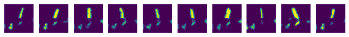

```python
D = {0,1,2,3,4,5,6,7,8,9}
#Plot the test data
fig, axs = plt.subplots(1,10,sharex=True , figsize=(10,10))
for j in D:
  axs[j].imshow(x_1_f[j],vmin=0, vmax=1)
  axs[j].axis('off')
```

Digit '2' Take 10 images from test data having their digit class as '2'. These are the original images

```
Shape of X_2 (10, 28, 28)
```

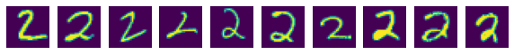

```python
# Take 10 images from test data having their digit class as '2'
X_2 = x_test[y_test == 2][:10]
print("Shape of X_2",X_2.shape)

#Plot the test data
fig, axs = plt.subplots(1,10,sharex=True , figsize=(10,10))
for j in range(10):
  axs[j].imshow(X_2[j])
  axs[j].axis('off')
```

```python
# First 8 patches for digit '2' for 10 test samples
d_2 = x_test1[y_test == 2][:10]
d_22 = d_2[:10:,0:8,:]
d_22.shape
```

```
(10, 8, 49)
```

```python
for i in range(8,16,1):
  print(f"predicting {i+1}-th frame")
  if i == 8:
    updated_2_n = np.concatenate((d_22, model.predict(d_22)[:,np.newaxis, -1,:]), axis=1)
  else:
    updated_2_n = np.concatenate((updated_2_n, model.predict(updated_2_n)[:,np.newaxis, -1,:]), axis=1)
# predicted_dict[i]
updated_2_n.shape
```

```
predicting 9-th frame
predicting 10-th frame
predicting 11-th frame
predicting 12-th frame
predicting 13-th frame
predicting 14-th frame
predicting 15-th frame
predicting 16-th frame
```

```
(10, 16, 49)
```

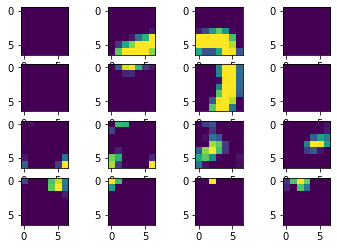

```python
for col in range(16):
  plt.subplot(4, 4, col+1)
  plt.imshow(updated_2_n[7][col].reshape(7,7))
```

```python
l2_1 = [0,1,2,3,4,5,6,7,8,9,10,11,12,13,14,15]
a2_1 =[]
for i in l2_1:
    b2_1 = updated_2_n[0,i,:].reshape(7,7)
    a2_1.append(b2_1)
c2_1=np.array(a2_1)

t2_1 = (c2_1[0], c2_1[1],c2_1[2],c2_1[3])
ct2_1 = np.concatenate(t2_1,axis=1)
r2_1 = ct2_1.reshape(-1,28)

t21_1 = (c2_1[4], c2_1[5],c2_1[6],c2_1[7])
ct21_1 = np.concatenate(t21_1,axis=1)
r21_1 = ct21_1.reshape(-1,28)

t22_1 = (c2_1[8], c2_1[9], c2_1[10],c2_1[11])
ct22_1 = np.concatenate(t22_1,axis=1)
r22_1 = ct22_1.reshape(-1,28)

t23_1 = (c2_1[12], c2_1[13], c2_1[14],c2_1[15])
ct23_1 = np.concatenate(t23_1,axis=1)
r23_1 = ct23_1.reshape(-1,28)

m2_1 = (ct2_1,ct21_1,ct22_1,ct23_1)
final_2_1 = np.concatenate(m2_1,axis=0)

final22_1 = final_2_1.reshape(-1,28,28)

######################################################
l2_2 = [0,1,2,3,4,5,6,7,8,9,10,11,12,13,14,15]
a2_2 =[]
for i in l2_2:
    b2_2 = updated_2_n[1,i,:].reshape(7,7)
    a2_2.append(b2_2)
c2_2=np.array(a2_2)

t2_2 = (c2_2[0], c2_2[1], c2_2[2],c2_2[3])
ct2_2 = np.concatenate(t2_2,axis=1)
r2_2 = ct2_2.reshape(-1,28)

t21_2 = (c2_2[4], c2_2[5],c2_2[6],c2_2[7])
ct21_2 = np.concatenate(t21_2,axis=1)
r21_2 = ct21_2.reshape(-1,28)

t22_2 = (c2_2[8], c2_2[9], c2_2[10],c2_2[11])
ct22_2 = np.concatenate(t22_2,axis=1)
r22_2 = ct22_2.reshape(-1,28)

t23_2 = (c2_2[12], c2_2[13], c2_2[14],c2_2[15])
ct23_2 = np.concatenate(t23_2,axis=1)
r23_2 = ct23_2.reshape(-1,28)

m2_2 = (ct2_2,ct21_2,ct22_2,ct23_2)
final_2_2 = np.concatenate(m2_2,axis=0)

final22_2 = final_2_2.reshape(-1,28,28)

#############################################
l2_3 = [0,1,2,3,4,5,6,7,8,9,10,11,12,13,14,15]
a2_3 =[]
for i in l2_3:
    b2_3 = updated_2_n[2,i,:].reshape(7,7)
    a2_3.append(b2_3)
c2_3=np.array(a2_3)

t2_3 = (c2_3[0], c2_3[1], c2_3[2],c2_3[3])
ct2_3 = np.concatenate(t2_3,axis=1)
r2_3 = ct2_3.reshape(-1,28)

t21_3 = (c2_3[4], c2_3[5],c2_3[6],c2_3[7])
ct21_3 = np.concatenate(t21_3,axis=1)
r21_3 = ct21_3.reshape(-1,28)

t22_3 = (c2_3[8], c2_3[9], c2_3[10],c2_3[11])
ct22_3 = np.concatenate(t22_3,axis=1)
r22_3 = ct22_3.reshape(-1,28)

t23_3 = (c2_3[12], c2_3[13], c2_3[14],c2_3[15])
ct23_3 = np.concatenate(t23_3,axis=1)
r23_3 = ct23_3.reshape(-1,28)

m2_3 = (ct2_3,ct21_3,ct22_3,ct23_3)
final_2_3 = np.concatenate(m2_3,axis=0)

final22_3 = final_2_3.reshape(-1,28,28)
########################################
l2_4 = [0,1,2,3,4,5,6,7,8,9,10,11,12,13,14,15]
a2_4 =[]
for i in l2_4:
    b2_4 = updated_2_n[3,i,:].reshape(7,7)
    a2_4.append(b2_4)
c2_4=np.array(a2_4)

t2_4 = (c2_4[0], c2_4[1], c2_4[2],c2_4[3])
ct2_4 = np.concatenate(t2_4,axis=1)
r2_4 = ct2_4.reshape(-1,28)

t21_4 = (c2_4[4],c2_4[5],c2_4[6],c2_4[7])
ct21_4 = np.concatenate(t21_4,axis=1)
r21_4 = ct21_4.reshape(-1,28)

t22_4 = (c2_4[8], c2_4[9], c2_4[10],c2_4[11])
ct22_4 = np.concatenate(t22_4,axis=1)
r22_4 = ct22_4.reshape(-1,28)

t23_4 = (c2_4[12], c2_4[13],c2_4[14],c2_4[15])
ct23_4 = np.concatenate(t23_4,axis=1)
r23_4 = ct23_4.reshape(-1,28)

m2_4 = (ct2_4,ct21_4,ct22_4,ct23_4)
final_2_4 = np.concatenate(m2_4,axis=0)

final22_4 = final_2_4.reshape(-1,28,28)
final22_4.shape

########################################################
l2_5 = [0,1,2,3,4,5,6,7,8,9,10,11,12,13,14,15]
a2_5 =[]
for i in l2_5:
    b2_5 = updated_2_n[4,i,:].reshape(7,7)
    a2_5.append(b2_5)
c2_5=np.array(a2_5)

t2_5 = (c2_5[0], c2_5[1], c2_5[2],c2_5[3])
ct2_5 = np.concatenate(t2_5,axis=1)
r2_5 = ct2_5.reshape(-1,28)

t21_5 = (c2_5[4],c2_5[5],c2_5[6],c2_5[7])
ct21_5 = np.concatenate(t21_5,axis=1)
r21_5 = ct21_5.reshape(-1,28)

t22_5 = (c2_5[8], c2_5[9], c2_5[10],c2_5[11])
ct22_5 = np.concatenate(t22_5,axis=1)
r22_5 = ct22_5.reshape(-1,28)

t23_5 = (c2_5[12], c2_5[13],c2_5[14],c2_5[15])
ct23_5 = np.concatenate(t23_5,axis=1)
r23_5 = ct23_5.reshape(-1,28)

m2_5 = (ct2_5,ct21_5,ct22_5,ct23_5)
final_2_5 = np.concatenate(m2_5,axis=0)

final22_5 = final_2_5.reshape(-1,28,28)
########################################################
l2_6 = [0,1,2,3,4,5,6,7,8,9,10,11,12,13,14,15]
a2_6 =[]
for i in l2_6:
    b2_6 = updated_2_n[5,i,:].reshape(7,7)
    a2_6.append(b2_6)
c2_6=np.array(a2_6)

t2_6 = (c2_6[0], c2_6[1], c2_6[2],c2_6[3])
ct2_6 = np.concatenate(t2_6,axis=1)
r2_6 = ct2_6.reshape(-1,28)

t21_6 = (c2_6[4],c2_6[5],c2_6[6],c2_6[7])
ct21_6 = np.concatenate(t21_6,axis=1)
r21_6 = ct21_6.reshape(-1,28)

t22_6 = (c2_6[8], c2_6[9], c2_6[10],c2_6[11])
ct22_6 = np.concatenate(t22_6,axis=1)
r22_6 = ct22_6.reshape(-1,28)

t23_6 = (c2_6[12], c2_6[13],c2_6[14],c2_6[15])
ct23_6 = np.concatenate(t23_6,axis=1)
r23_6 = ct23_6.reshape(-1,28)

m2_6 = (ct2_6,ct21_6,ct22_6,ct23_6)
final_2_6 = np.concatenate(m2_6,axis=0)

final22_6 = final_2_6.reshape(-1,28,28)
####################################################
l2_7 = [0,1,2,3,4,5,6,7,8,9,10,11,12,13,14,15]
a2_7 =[]
for i in l2_7:
    b2_7 = updated_2_n[6,i,:].reshape(7,7)
    a2_7.append(b2_7)
c2_7=np.array(a2_7)

t2_7 = (c2_7[0], c2_7[1], c2_7[2],c2_7[3])
ct2_7 = np.concatenate(t2_7,axis=1)
r2_7 = ct2_7.reshape(-1,28)

t21_7 = (c2_7[4],c2_7[5],c2_7[6],c2_7[7])
ct21_7 = np.concatenate(t21_7,axis=1)
r21_7 = ct21_7.reshape(-1,28)

t22_7 = (c2_7[8], c2_7[9], c2_7[10],c2_7[11])
ct22_7 = np.concatenate(t22_7,axis=1)
r22_7 = ct22_7.reshape(-1,28)

t23_7 = (c2_7[12], c2_7[13],c2_7[14],c2_7[15])
ct23_7 = np.concatenate(t23_7,axis=1)
r23_7 = ct23_7.reshape(-1,28)

m2_7 = (ct2_7,ct21_7,ct22_7,ct23_7)
final_2_7 = np.concatenate(m2_7,axis=0)

final22_7 = final_2_7.reshape(-1,28,28)
####################################################
l2_8 = [0,1,2,3,4,5,6,7,8,9,10,11,12,13,14,15]
a2_8 =[]
for i in l2_8:
    b2_8 = updated_2_n[7,i,:].reshape(7,7)
    a2_8.append(b2_8)
c2_8=np.array(a2_8)

t2_8 = (c2_8[0], c2_8[1], c2_8[2],c2_8[3])
ct2_8 = np.concatenate(t2_8,axis=1)
r2_8 = ct2_8.reshape(-1,28)

t21_8 = (c2_8[4],c2_8[5],c2_8[6],c2_8[7])
ct21_8 = np.concatenate(t21_8,axis=1)
r21_8 = ct21_8.reshape(-1,28)

t22_8 = (c2_8[8], c2_8[9], c2_8[10],c2_8[11])
ct22_8 = np.concatenate(t22_8,axis=1)
r22_8 = ct22_8.reshape(-1,28)

t23_8 = (c2_8[12], c2_8[13],c2_8[14],c2_8[15])
ct23_8 = np.concatenate(t23_8,axis=1)
r23_8 = ct23_8.reshape(-1,28)

m2_8 = (ct2_8,ct21_8,ct22_8,ct23_8)
final_2_8 = np.concatenate(m2_8,axis=0)

final22_8 = final_2_8.reshape(-1,28,28)
###################################################
l2_9 = [0,1,2,3,4,5,6,7,8,9,10,11,12,13,14,15]
a2_9 =[]
for i in l2_9:
    b2_9 = updated_2_n[8,i,:].reshape(7,7)
    a2_9.append(b2_9)
c2_9=np.array(a2_9)

t2_9 = (c2_9[0], c2_9[1], c2_9[2],c2_9[3])
ct2_9 = np.concatenate(t2_9,axis=1)
r2_9 = ct2_9.reshape(-1,28)

t21_9 = (c2_9[4],c2_9[5],c2_9[6],c2_9[7])
ct21_9 = np.concatenate(t21_9,axis=1)
r21_9 = ct21_9.reshape(-1,28)

t22_9 = (c2_9[8], c2_9[9], c2_9[10],c2_9[11])
ct22_9 = np.concatenate(t22_9,axis=1)
r22_9 = ct22_9.reshape(-1,28)

t23_9 = (c2_9[12], c2_9[13],c2_9[14],c2_9[15])
ct23_9 = np.concatenate(t23_9,axis=1)
r23_9 = ct23_9.reshape(-1,28)

m2_9 = (ct2_9,ct21_9,ct22_9,ct23_9)
final_2_9 = np.concatenate(m2_9,axis=0)

final22_9 = final_2_9.reshape(-1,28,28)
################################################

l2_a = [0,1,2,3,4,5,6,7,8,9,10,11,12,13,14,15]
a2_a =[]
for i in l2_a:
    b2_a = updated_2_n[9,i,:].reshape(7,7)
    a2_a.append(b2_a)
c2_a=np.array(a2_a)

t2_a = (c2_a[0], c2_a[1], c2_a[2],c2_a[3])
ct2_a = np.concatenate(t2_a,axis=1)
r2_a = ct2_a.reshape(-1,28)

t21_a = (c2_a[4],c2_a[5],c2_a[6],c2_a[7])
ct21_a = np.concatenate(t21_a,axis=1)
r21_a = ct21_a.reshape(-1,28)

t22_a = (c2_a[8], c2_a[9], c2_a[10],c2_a[11])
ct22_a = np.concatenate(t22_a,axis=1)
r22_a = ct22_a.reshape(-1,28)

t23_a = (c2_a[12], c2_a[13],c2_a[14],c2_a[15])
ct23_a = np.concatenate(t23_a,axis=1)
r23_a = ct23_a.reshape(-1,28)

m2_a = (ct2_a,ct21_a,ct22_a,ct23_a)
final_2_a = np.concatenate(m2_a,axis=0)

final22_a = final_2_a.reshape(-1,28,28)
```

```python
#x_0 = (final_0_1,final_01,final_0_2,final_0_3,final_0_4,final_0_5,final_0_6,final_0_7,final_0_8,final_0_9)
x_2= (final22_1,final22_2,final22_3,final22_4,final22_5,final22_6,final22_7,final22_8,final22_9,final22_a)
x_2_f = np.concatenate(x_2,axis=0)
x_2_f.shape
```

```
(10, 28, 28)
```

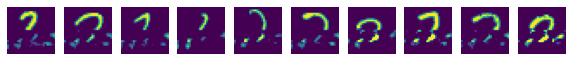

```python
D = {0,1,2,3,4,5,6,7,8,9}
#Plot the test data
fig, axs = plt.subplots(1,10,sharex=True , figsize=(10,10))
for j in D:
  axs[j].imshow(x_2_f[j],vmin=0, vmax=1)
  axs[j].axis('off')
```

Digit '3' Take 10 images from test data having their digit class as '3'. These are the original images

```
Shape of X_3 (10, 28, 28)
```

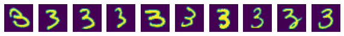

```python
# Take 10 images from test data having their digit class as '3'
X_3 = x_test[y_test == 3][:10]
print("Shape of X_3",X_3.shape)

#Plot the test data
fig, axs = plt.subplots(1,10,sharex=True , figsize=(10,10))
for j in range(10):
  axs[j].imshow(X_3[j])
  axs[j].axis('off')
```

```python
# First 8 patches for digit '3' for 10 test samples
d_3 = x_test1[y_test == 3][:10]
d_33 = d_3[:10:,0:8,:]
d_33.shape
```

```
(10, 8, 49)
```

```python
for i in range(8,16,1):
  print(f"predicting {i+1}-th frame")
  if i == 8:
    updated_3_n = np.concatenate((d_33, model.predict(d_33)[:,np.newaxis, -1,:]), axis=1)
  else:
    updated_3_n = np.concatenate((updated_3_n, model.predict(updated_3_n)[:,np.newaxis, -1,:]), axis=1)
# predicted_dict[i]
updated_3_n.shape
```

```
predicting 9-th frame
predicting 10-th frame
predicting 11-th frame
predicting 12-th frame
predicting 13-th frame
predicting 14-th frame
predicting 15-th frame
predicting 16-th frame
```

```
(10, 16, 49)
```

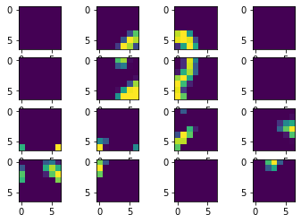

```python
for col in range(16):
  plt.subplot(4, 4, col+1)
  plt.imshow(updated_3_n[7][col].reshape(7,7))
```

```python
l3_1 = [0,1,2,3,4,5,6,7,8,9,10,11,12,13,14,15]
a3_1 =[]
for i in l3_1:
    b3_1 = updated_3_n[0,i,:].reshape(7,7)
    a3_1.append(b3_1)
c3_1=np.array(a3_1)

t3_1 = (c3_1[0], c3_1[1],c3_1[2],c3_1[3])
ct3_1 = np.concatenate(t3_1,axis=1)
r3_1 = ct3_1.reshape(-1,28)

t31_1 = (c3_1[4], c3_1[5],c3_1[6],c3_1[7])
ct31_1 = np.concatenate(t31_1,axis=1)
r31_1 = ct31_1.reshape(-1,28)

t32_1 = (c3_1[8], c3_1[9], c3_1[10],c3_1[11])
ct32_1 = np.concatenate(t32_1,axis=1)
r32_1 = ct32_1.reshape(-1,28)

t33_1 = (c3_1[12], c3_1[13], c3_1[14],c3_1[15])
ct33_1 = np.concatenate(t33_1,axis=1)
r33_1 = ct33_1.reshape(-1,28)

m3_1 = (ct3_1,ct31_1,ct32_1,ct33_1)
final_3_1 = np.concatenate(m3_1,axis=0)
final33_1 = final_3_1.reshape(-1,28,28)

####################################################
l3_2 = [0,1,2,3,4,5,6,7,8,9,10,11,12,13,14,15]
a3_2 =[]
for i in l3_2:
    b3_2 = updated_3_n[1,i,:].reshape(7,7)
    a3_2.append(b3_2)
c3_2=np.array(a3_2)

t3_2 = (c3_2[0], c3_2[1], c3_2[2],c3_2[3])
ct3_2 = np.concatenate(t3_2,axis=1)
r3_2 = ct3_2.reshape(-1,28)

t31_2 = (c3_2[4], c3_2[5],c3_2[6],c3_2[7])
ct31_2 = np.concatenate(t31_2,axis=1)
r31_2 = ct31_2.reshape(-1,28)

t32_2 = (c3_2[8], c3_2[9], c3_2[10],c3_2[11])
ct32_2 = np.concatenate(t32_2,axis=1)
r32_2 = ct32_2.reshape(-1,28)

t33_2 = (c3_2[12], c3_2[13], c3_2[14],c3_2[15])
ct33_2 = np.concatenate(t33_2,axis=1)
r33_2 = ct33_2.reshape(-1,28)

m3_2 = (ct3_2,ct31_2,ct32_2,ct33_2)
final_3_2 = np.concatenate(m3_2,axis=0)

final33_2 = final_3_2.reshape(-1,28,28)

############################################
l3_3 = [0,1,2,3,4,5,6,7,8,9,10,11,12,13,14,15]
a3_3 =[]
for i in l3_3:
    b3_3 = updated_3_n[2,i,:].reshape(7,7)
    a3_3.append(b3_3)
c3_3=np.array(a2_3)

t3_3 = (c3_3[0], c3_3[1], c3_3[2],c3_3[3])
ct3_3 = np.concatenate(t3_3,axis=1)
r3_3 = ct2_3.reshape(-1,28)

t31_3 = (c3_3[4], c3_3[5],c3_3[6],c3_3[7])
ct31_3 = np.concatenate(t31_3,axis=1)
r31_3 = ct31_3.reshape(-1,28)

t32_3 = (c3_3[8], c3_3[9], c3_3[10],c3_3[11])
ct32_3 = np.concatenate(t32_3,axis=1)
r32_3 = ct32_3.reshape(-1,28)

t33_3 = (c3_3[12], c3_3[13], c3_3[14],c3_3[15])
ct33_3 = np.concatenate(t33_3,axis=1)
r33_3 = ct33_3.reshape(-1,28)

m3_3 = (ct3_3,ct31_3,ct32_3,ct33_3)
final_3_3 = np.concatenate(m3_3,axis=0)

final33_3 = final_3_3.reshape(-1,28,28)
################################################
l3_4 = [0,1,2,3,4,5,6,7,8,9,10,11,12,13,14,15]
a3_4 =[]
for i in l3_4:
    b3_4 = updated_3_n[3,i,:].reshape(7,7)
    a3_4.append(b3_4)
c3_4=np.array(a3_4)

t3_4 = (c3_4[0], c3_4[1], c3_4[2],c3_4[3])
ct3_4 = np.concatenate(t3_4,axis=1)
r3_4 = ct3_4.reshape(-1,28)

t31_4 = (c3_4[4],c3_4[5],c3_4[6],c3_4[7])
ct31_4 = np.concatenate(t31_4,axis=1)
r31_4 = ct31_4.reshape(-1,28)

t32_4 = (c3_4[8], c3_4[9], c3_4[10],c3_4[11])
ct32_4 = np.concatenate(t32_4,axis=1)
r32_4 = ct32_4.reshape(-1,28)

t33_4 = (c3_4[12], c3_4[13],c3_4[14],c3_4[15])
ct33_4 = np.concatenate(t33_4,axis=1)
r33_4 = ct33_4.reshape(-1,28)

m3_4 = (ct2_4,ct21_4,ct22_4,ct23_4)
final_3_4 = np.concatenate(m3_4,axis=0)

final33_4 = final_3_4.reshape(-1,28,28)
##################################################

l3_5 = [0,1,2,3,4,5,6,7,8,9,10,11,12,13,14,15]
a3_5 =[]
for i in l3_5:
    b3_5 = updated_3_n[4,i,:].reshape(7,7)
    a3_5.append(b3_5)
c3_5=np.array(a3_5)

t3_5 = (c3_5[0], c3_5[1], c3_5[2],c3_5[3])
ct3_5 = np.concatenate(t3_5,axis=1)
r3_5 = ct3_5.reshape(-1,28)

t31_5 = (c3_5[4],c3_5[5],c3_5[6],c3_5[7])
ct31_5 = np.concatenate(t31_5,axis=1)
r31_5 = ct31_5.reshape(-1,28)

t32_5 = (c3_5[8], c3_5[9], c3_5[10],c3_5[11])
ct32_5 = np.concatenate(t32_5,axis=1)
r32_5 = ct32_5.reshape(-1,28)

t33_5 = (c3_5[12], c3_5[13],c3_5[14],c3_5[15])
ct33_5 = np.concatenate(t33_5,axis=1)
r33_5 = ct33_5.reshape(-1,28)

m3_5 = (ct3_5,ct31_5,ct32_5,ct33_5)
final_3_5 = np.concatenate(m3_5,axis=0)

final33_5 = final_3_5.reshape(-1,28,28)

#################################################

l3_6 = [0,1,2,3,4,5,6,7,8,9,10,11,12,13,14,15]
a3_6 =[]
for i in l3_6:
    b3_6 = updated_3_n[5,i,:].reshape(7,7)
    a3_6.append(b3_6)
c3_6=np.array(a3_6)

t3_6 = (c3_6[0], c3_6[1], c3_6[2],c3_6[3])
ct3_6 = np.concatenate(t3_6,axis=1)
r3_6 = ct3_6.reshape(-1,28)

t31_6 = (c3_6[4],c3_6[5],c3_6[6],c3_6[7])
ct31_6 = np.concatenate(t31_6,axis=1)
r31_6 = ct31_6.reshape(-1,28)

t32_6 = (c3_6[8], c3_6[9], c3_6[10],c3_6[11])
ct32_6 = np.concatenate(t32_6,axis=1)
r32_6 = ct32_6.reshape(-1,28)

t33_6 = (c3_6[12], c3_6[13],c3_6[14],c3_6[15])
ct33_6 = np.concatenate(t33_6,axis=1)
r33_6 = ct33_6.reshape(-1,28)

m3_6 = (ct3_6,ct31_6,ct32_6,ct33_6)
final_3_6 = np.concatenate(m3_6,axis=0)

final33_6 = final_3_6.reshape(-1,28,28)

#####################################################
l3_7 = [0,1,2,3,4,5,6,7,8,9,10,11,12,13,14,15]
a3_7 =[]
for i in l3_7:
    b3_7 = updated_3_n[6,i,:].reshape(7,7)
    a3_7.append(b3_7)
c3_7=np.array(a3_7)

t3_7 = (c3_7[0], c3_7[1], c3_7[2],c3_7[3])
ct3_7 = np.concatenate(t3_7,axis=1)
r3_7 = ct3_7.reshape(-1,28)

t31_7 = (c3_7[4],c3_7[5],c3_7[6],c3_7[7])
ct31_7 = np.concatenate(t31_7,axis=1)
r31_7 = ct31_7.reshape(-1,28)

t32_7 = (c3_7[8], c3_7[9], c3_7[10],c3_7[11])
ct32_7 = np.concatenate(t32_7,axis=1)
r32_7 = ct32_7.reshape(-1,28)

t33_7 = (c3_7[12], c3_7[13],c3_7[14],c3_7[15])
ct33_7 = np.concatenate(t33_7,axis=1)
r33_7 = ct33_7.reshape(-1,28)

m3_7 = (ct3_7,ct31_7,ct32_7,ct33_7)
final_3_7 = np.concatenate(m3_7,axis=0)

final33_7 = final_3_7.reshape(-1,28,28)

##################################################
l3_8 = [0,1,2,3,4,5,6,7,8,9,10,11,12,13,14,15]
a3_8 =[]
for i in l3_8:
    b3_8 = updated_3_n[7,i,:].reshape(7,7)
    a3_8.append(b3_8)
c3_8=np.array(a3_8)

t3_8 = (c3_8[0], c3_8[1], c3_8[2],c3_8[3])
ct3_8 = np.concatenate(t3_8,axis=1)
r3_8 = ct3_8.reshape(-1,28)

t31_8 = (c3_8[4],c3_8[5],c3_8[6],c3_8[7])
ct31_8 = np.concatenate(t31_8,axis=1)
r31_8 = ct31_8.reshape(-1,28)

t32_8 = (c3_8[8], c3_8[9], c3_8[10],c3_8[11])
ct32_8 = np.concatenate(t32_8,axis=1)
r32_8 = ct32_8.reshape(-1,28)

t33_8 = (c3_8[12], c3_8[13],c3_8[14],c3_8[15])
ct33_8 = np.concatenate(t33_8,axis=1)
r33_8 = ct33_8.reshape(-1,28)

m3_8 = (ct3_8,ct31_8,ct32_8,ct33_8)
final_3_8 = np.concatenate(m3_8,axis=0)

final33_8 = final_3_8.reshape(-1,28,28)
final33_8.shape
##############################################################

l3_9 = [0,1,2,3,4,5,6,7,8,9,10,11,12,13,14,15]
a3_9 =[]
for i in l3_9:
    b3_9 = updated_3_n[8,i,:].reshape(7,7)
    a3_9.append(b3_9)
c3_9=np.array(a3_9)

t3_9 = (c3_9[0], c3_9[1], c3_9[2],c3_9[3])
ct3_9 = np.concatenate(t3_9,axis=1)
r3_9 = ct3_9.reshape(-1,28)

t31_9 = (c3_9[4],c3_9[5],c3_9[6],c3_9[7])
ct31_9 = np.concatenate(t31_9,axis=1)
r31_9 = ct31_9.reshape(-1,28)

t32_9 = (c3_9[8], c3_9[9], c3_9[10],c3_9[11])
ct32_9 = np.concatenate(t32_9,axis=1)
r32_9 = ct32_9.reshape(-1,28)

t33_9 = (c3_9[12], c3_9[13],c3_9[14],c3_9[15])
ct33_9 = np.concatenate(t33_9,axis=1)
r33_9 = ct33_9.reshape(-1,28)

m3_9 = (ct3_9,ct31_9,ct32_9,ct33_9)
final_3_9 = np.concatenate(m3_9,axis=0)

final33_9 = final_3_9.reshape(-1,28,28)

###############################################
l3_a = [0,1,2,3,4,5,6,7,8,9,10,11,12,13,14,15]
a3_a =[]
for i in l3_a:
    b3_a = updated_3_n[9,i,:].reshape(7,7)
    a3_a.append(b3_a)
c3_a=np.array(a3_a)

t3_a = (c3_a[0], c3_a[1], c3_a[2],c3_a[3])
ct3_a = np.concatenate(t3_a,axis=1)
r3_a = ct3_a.reshape(-1,28)

t31_a = (c3_a[4],c3_a[5],c3_a[6],c3_a[7])
ct31_a = np.concatenate(t31_a,axis=1)
r31_a = ct31_a.reshape(-1,28)

t32_a = (c3_a[8], c3_a[9], c3_a[10],c3_a[11])
ct32_a = np.concatenate(t32_a,axis=1)
r32_a = ct32_a.reshape(-1,28)

t33_a = (c3_a[12], c3_a[13],c3_a[14],c3_a[15])
ct33_a = np.concatenate(t33_a,axis=1)
r33_a = ct33_a.reshape(-1,28)

m3_a = (ct3_a,ct31_a,ct32_a,ct33_a)
final_3_a = np.concatenate(m3_a,axis=0)

final33_a = final_3_a.reshape(-1,28,28)
```

```python
#x_0 = (final_0_1,final_01,final_0_2,final_0_3,final_0_4,final_0_5,final_0_6,final_0_7,final_0_8,final_0_9)
x_3= (final33_1,final33_2,final33_3,final33_4,final33_5,final33_6,final33_7,final33_8,final33_9,final33_a)
x_3_f = np.concatenate(x_3,axis=0)
x_3_f.shape
```

```
(10, 28, 28)
```

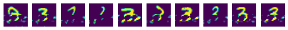

```python
D = {0,1,2,3,4,5,6,7,8,9}
#Plot the test data
fig, axs = plt.subplots(1,10,sharex=True , figsize=(10,10))
for j in D:
  axs[j].imshow(x_3_f[j],vmin=0, vmax=1)
  axs[j].axis('off')
```

Digit '4' Take 10 images from test data having their digit class as '4'. These are the original images

```
Shape of X_4 (10, 28, 28)
```

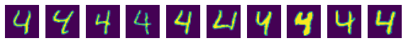

```python
# Take 10 images from test data having their digit class as '4'
X_4 = x_test[y_test == 4][:10]
print("Shape of X_4",X_4.shape)

#Plot the test data
fig, axs = plt.subplots(1,10,sharex=True , figsize=(10,10))
for j in range(10):
  axs[j].imshow(X_4[j])
  axs[j].axis('off')
```

```python
# First 8 patches for digit '4' for 10 test samples
d_4 = x_test1[y_test == 4][:10]
d_44 = d_4[:10:,0:8,:]
d_44.shape
```

```
(10, 8, 49)
```

```python
for i in range(8,16,1):
  print(f"predicting {i+1}-th frame")
  if i == 8:
    updated_4_n = np.concatenate((d_44, model.predict(d_44)[:,np.newaxis, -1,:]), axis=1)
  else:
    updated_4_n = np.concatenate((updated_4_n, model.predict(updated_4_n)[:,np.newaxis, -1,:]), axis=1)
# predicted_dict[i]
updated_4_n.shape
```

```
predicting 9-th frame
predicting 10-th frame
predicting 11-th frame
predicting 12-th frame
predicting 13-th frame
predicting 14-th frame
predicting 15-th frame
predicting 16-th frame
```

```
(10, 16, 49)
```

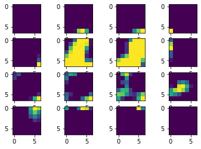

```python
for col in range(16):
  plt.subplot(4, 4, col+1)
  plt.imshow(updated_4_n[7][col].reshape(7,7))
```

```python
l4_1 = [0,1,2,3,4,5,6,7,8,9,10,11,12,13,14,15]
a4_1 =[]
for i in l4_1:
    b4_1 = updated_4_n[0,i,:].reshape(7,7)
    a4_1.append(b4_1)
c4_1=np.array(a4_1)

t4_1 = (c4_1[0], c4_1[1],c4_1[2],c4_1[3])
ct4_1 = np.concatenate(t4_1,axis=1)
r4_1 = ct4_1.reshape(-1,28)

t41_1 = (c4_1[4], c4_1[5],c4_1[6],c4_1[7])
ct41_1 = np.concatenate(t41_1,axis=1)
r41_1 = ct41_1.reshape(-1,28)

t42_1 = (c4_1[8], c4_1[9], c4_1[10],c4_1[11])
ct42_1 = np.concatenate(t42_1,axis=1)
r42_1 = ct42_1.reshape(-1,28)

t43_1 = (c4_1[12], c4_1[13], c4_1[14],c4_1[15])
ct43_1 = np.concatenate(t43_1,axis=1)
r43_1 = ct43_1.reshape(-1,28)

m4_1 = (ct4_1,ct41_1,ct42_1,ct43_1)
final_4_1 = np.concatenate(m4_1,axis=0)
final44_1 = final_4_1.reshape(-1,28,28)

####################################################
l4_2 = [0,1,2,3,4,5,6,7,8,9,10,11,12,13,14,15]
a4_2 =[]
for i in l4_2:
    b4_2 = updated_4_n[1,i,:].reshape(7,7)
    a4_2.append(b4_2)
c4_2=np.array(a4_2)

t4_2 = (c4_2[0], c4_2[1], c4_2[2],c4_2[3])
ct4_2 = np.concatenate(t4_2,axis=1)
r4_2 = ct4_2.reshape(-1,28)

t41_2 = (c4_2[4], c4_2[5],c4_2[6],c4_2[7])
ct41_2 = np.concatenate(t41_2,axis=1)
r41_2 = ct41_2.reshape(-1,28)

t42_2 = (c4_2[8], c4_2[9], c4_2[10],c4_2[11])
ct42_2 = np.concatenate(t42_2,axis=1)
r42_2 = ct42_2.reshape(-1,28)

t43_2 = (c4_2[12], c4_2[13], c4_2[14],c4_2[15])
ct43_2 = np.concatenate(t43_2,axis=1)
r43_2 = ct43_2.reshape(-1,28)

m4_2 = (ct4_2,ct41_2,ct42_2,ct43_2)
final_4_2 = np.concatenate(m4_2,axis=0)

final44_2 = final_4_2.reshape(-1,28,28)

############################################
l4_3 = [0,1,2,3,4,5,6,7,8,9,10,11,12,13,14,15]
a4_3 =[]
for i in l4_3:
    b4_3 = updated_4_n[2,i,:].reshape(7,7)
    a4_3.append(b4_3)
c4_3=np.array(a4_3)

t4_3 = (c4_3[0], c4_3[1], c4_3[2],c4_3[3])
ct4_3 = np.concatenate(t4_3,axis=1)
r4_3 = ct4_3.reshape(-1,28)

t41_3 = (c4_3[4], c4_3[5],c4_3[6],c4_3[7])
ct41_3 = np.concatenate(t41_3,axis=1)
r41_3 = ct41_3.reshape(-1,28)

t42_3 = (c4_3[8], c4_3[9], c4_3[10],c4_3[11])
ct42_3 = np.concatenate(t42_3,axis=1)
r42_3 = ct42_3.reshape(-1,28)

t43_3 = (c4_3[12], c4_3[13], c4_3[14],c4_3[15])
ct43_3 = np.concatenate(t43_3,axis=1)
r43_3 = ct43_3.reshape(-1,28)

m4_3 = (ct4_3,ct41_3,ct42_3,ct43_3)
final_4_3 = np.concatenate(m4_3,axis=0)

final44_3 = final_4_3.reshape(-1,28,28)
################################################
l4_4 = [0,1,2,3,4,5,6,7,8,9,10,11,12,13,14,15]
a4_4 =[]
for i in l3_4:
    b4_4 = updated_4_n[3,i,:].reshape(7,7)
    a4_4.append(b4_4)
c4_4=np.array(a4_4)

t4_4 = (c4_4[0], c4_4[1], c4_4[2],c4_4[3])
ct4_4 = np.concatenate(t4_4,axis=1)
r4_4 = ct4_4.reshape(-1,28)

t41_4 = (c4_4[4],c4_4[5],c4_4[6],c4_4[7])
ct41_4 = np.concatenate(t41_4,axis=1)
r41_4 = ct41_4.reshape(-1,28)

t42_4 = (c4_4[8], c4_4[9], c4_4[10],c4_4[11])
ct42_4 = np.concatenate(t42_4,axis=1)
r42_4 = ct42_4.reshape(-1,28)

t43_4 = (c4_4[12], c4_4[13],c4_4[14],c4_4[15])
ct43_4 = np.concatenate(t43_4,axis=1)
r43_4 = ct43_4.reshape(-1,28)

m4_4 = (ct4_4,ct41_4,ct42_4,ct43_4)
final_4_4 = np.concatenate(m4_4,axis=0)

final44_4 = final_4_4.reshape(-1,28,28)
##################################################

l4_5 = [0,1,2,3,4,5,6,7,8,9,10,11,12,13,14,15]
a4_5 =[]
for i in l4_5:
    b4_5 = updated_4_n[4,i,:].reshape(7,7)
    a4_5.append(b4_5)
c4_5=np.array(a4_5)

t4_5 = (c4_5[0], c4_5[1], c4_5[2],c4_5[3])
ct4_5 = np.concatenate(t4_5,axis=1)
r4_5 = ct4_5.reshape(-1,28)

t41_5 = (c4_5[4],c4_5[5],c4_5[6],c4_5[7])
ct41_5 = np.concatenate(t41_5,axis=1)
r41_5 = ct41_5.reshape(-1,28)

t42_5 = (c4_5[8], c4_5[9], c4_5[10],c4_5[11])
ct42_5 = np.concatenate(t42_5,axis=1)
r42_5 = ct42_5.reshape(-1,28)

t43_5 = (c4_5[12], c4_5[13],c4_5[14],c4_5[15])
ct43_5 = np.concatenate(t43_5,axis=1)
r43_5 = ct43_5.reshape(-1,28)

m4_5 = (ct4_5,ct41_5,ct42_5,ct43_5)
final_4_5 = np.concatenate(m4_5,axis=0)

final44_5 = final_4_5.reshape(-1,28,28)

#################################################

l4_6 = [0,1,2,3,4,5,6,7,8,9,10,11,12,13,14,15]
a4_6 =[]
for i in l4_6:
    b4_6 = updated_4_n[5,i,:].reshape(7,7)
    a4_6.append(b4_6)
c4_6=np.array(a4_6)

t4_6 = (c4_6[0], c4_6[1], c4_6[2],c4_6[3])
ct4_6 = np.concatenate(t4_6,axis=1)
r4_6 = ct4_6.reshape(-1,28)

t41_6 = (c4_6[4],c4_6[5],c4_6[6],c4_6[7])
ct41_6 = np.concatenate(t41_6,axis=1)
r41_6 = ct41_6.reshape(-1,28)

t42_6 = (c4_6[8], c4_6[9], c4_6[10],c4_6[11])
ct42_6 = np.concatenate(t42_6,axis=1)
r42_6 = ct42_6.reshape(-1,28)

t43_6 = (c4_6[12], c4_6[13],c4_6[14],c4_6[15])
ct43_6 = np.concatenate(t43_6,axis=1)
r43_6 = ct43_6.reshape(-1,28)

m4_6 = (ct4_6,ct41_6,ct42_6,ct43_6)
final_4_6 = np.concatenate(m4_6,axis=0)

final44_6 = final_4_6.reshape(-1,28,28)

#####################################################
l4_7 = [0,1,2,3,4,5,6,7,8,9,10,11,12,13,14,15]
a4_7 =[]
for i in l4_7:
    b4_7 = updated_4_n[6,i,:].reshape(7,7)
    a4_7.append(b4_7)
c4_7=np.array(a4_7)

t4_7 = (c4_7[0], c4_7[1], c4_7[2],c4_7[3])
ct4_7 = np.concatenate(t4_7,axis=1)
r4_7 = ct4_7.reshape(-1,28)

t41_7 = (c4_7[4],c4_7[5],c4_7[6],c4_7[7])
ct41_7 = np.concatenate(t41_7,axis=1)
r41_7 = ct41_7.reshape(-1,28)

t42_7 = (c4_7[8], c4_7[9], c4_7[10],c4_7[11])
ct42_7 = np.concatenate(t42_7,axis=1)
r42_7 = ct42_7.reshape(-1,28)

t43_7 = (c4_7[12], c4_7[13],c4_7[14],c4_7[15])
ct43_7 = np.concatenate(t43_7,axis=1)
r43_7 = ct43_7.reshape(-1,28)

m4_7 = (ct4_7,ct41_7,ct42_7,ct43_7)
final_4_7 = np.concatenate(m4_7,axis=0)

final44_7 = final_4_7.reshape(-1,28,28)

##################################################
l4_8 = [0,1,2,3,4,5,6,7,8,9,10,11,12,13,14,15]
a4_8 =[]
for i in l4_8:
    b4_8 = updated_4_n[7,i,:].reshape(7,7)
    a4_8.append(b4_8)
c4_8=np.array(a4_8)

t4_8 = (c4_8[0], c4_8[1], c4_8[2],c4_8[3])
ct4_8 = np.concatenate(t4_8,axis=1)
r4_8 = ct4_8.reshape(-1,28)

t41_8 = (c4_8[4],c4_8[5],c4_8[6],c4_8[7])
ct41_8 = np.concatenate(t41_8,axis=1)
r41_8 = ct41_8.reshape(-1,28)

t42_8 = (c4_8[8], c4_8[9], c4_8[10],c4_8[11])
ct42_8 = np.concatenate(t42_8,axis=1)
r42_8 = ct42_8.reshape(-1,28)

t43_8 = (c3_8[12], c3_8[13],c3_8[14],c3_8[15])
ct43_8 = np.concatenate(t43_8,axis=1)
r43_8 = ct43_8.reshape(-1,28)

m4_8 = (ct4_8,ct41_8,ct42_8,ct43_8)
final_4_8 = np.concatenate(m4_8,axis=0)

final44_8 = final_4_8.reshape(-1,28,28)
final44_8.shape
##############################################################

l4_9 = [0,1,2,3,4,5,6,7,8,9,10,11,12,13,14,15]
a4_9 =[]
for i in l4_9:
    b4_9 = updated_4_n[8,i,:].reshape(7,7)
    a4_9.append(b4_9)
c4_9=np.array(a4_9)

t4_9 = (c4_9[0], c4_9[1], c4_9[2],c4_9[3])
ct4_9 = np.concatenate(t4_9,axis=1)
r4_9 = ct4_9.reshape(-1,28)

t41_9 = (c4_9[4],c4_9[5],c4_9[6],c4_9[7])
ct41_9 = np.concatenate(t41_9,axis=1)
r41_9 = ct41_9.reshape(-1,28)

t42_9 = (c4_9[8],c4_9[9], c4_9[10],c4_9[11])
ct42_9 = np.concatenate(t42_9,axis=1)
r42_9 = ct42_9.reshape(-1,28)

t43_9 = (c4_9[12], c4_9[13],c4_9[14],c4_9[15])
ct43_9 = np.concatenate(t43_9,axis=1)
r43_9 = ct43_9.reshape(-1,28)

m4_9 = (ct4_9,ct41_9,ct42_9,ct43_9)
final_4_9 = np.concatenate(m4_9,axis=0)

final44_9 = final_4_9.reshape(-1,28,28)

###############################################
l4_a = [0,1,2,3,4,5,6,7,8,9,10,11,12,13,14,15]
a4_a =[]
for i in l4_a:
    b4_a = updated_4_n[9,i,:].reshape(7,7)
    a4_a.append(b4_a)
c4_a=np.array(a4_a)

t4_a = (c4_a[0], c4_a[1], c4_a[2],c4_a[3])
ct4_a = np.concatenate(t4_a,axis=1)
r4_a = ct4_a.reshape(-1,28)

t41_a = (c4_a[4],c4_a[5],c4_a[6],c4_a[7])
ct41_a = np.concatenate(t41_a,axis=1)
r41_a = ct41_a.reshape(-1,28)

t42_a = (c4_a[8], c4_a[9], c4_a[10],c4_a[11])
ct42_a = np.concatenate(t42_a,axis=1)
r42_a = ct42_a.reshape(-1,28)

t43_a = (c4_a[12], c4_a[13],c4_a[14],c4_a[15])
ct43_a = np.concatenate(t43_a,axis=1)
r43_a = ct43_a.reshape(-1,28)

m4_a = (ct4_a,ct41_a,ct42_a,ct43_a)
final_4_a = np.concatenate(m4_a,axis=0)

final44_a = final_4_a.reshape(-1,28,28)
```

```python
#x_0 = (final_0_1,final_01,final_0_2,final_0_3,final_0_4,final_0_5,final_0_6,final_0_7,final_0_8,final_0_9)
x_4= (final44_1,final44_2,final44_3,final44_4,final44_5,final44_6,final44_7,final44_8,final44_9,final44_a)
x_4_f = np.concatenate(x_4,axis=0)
x_4_f.shape
```

```
(10, 28, 28)
```

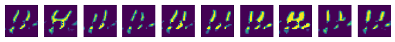

```python
D = {0,1,2,3,4,5,6,7,8,9}
#Plot the test data
fig, axs = plt.subplots(1,10,sharex=True , figsize=(10,10))
for j in D:
  axs[j].imshow(x_4_f[j],vmin=0, vmax=1)
  axs[j].axis('off')
```

Digit '5' Take 10 images from test data having their digit class as '5'. These are the original images

```
Shape of X_5 (10, 28, 28)
```

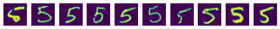

```python
# Take 10 images from test data having their digit class as '5'
X_5 = x_test[y_test == 5][:10]
print("Shape of X_5",X_5.shape)

#Plot the test data
fig, axs = plt.subplots(1,10,sharex=True , figsize=(10,10))
for j in range(10):
  axs[j].imshow(X_5[j])
  axs[j].axis('off')
```

```python
# First 8 patches for digit '4' for 10 test samples
d_5 = x_test1[y_test == 5][:10]
d_55 = d_5[:10:,0:8,:]
d_55.shape
```

```
(10, 8, 49)
```

```python
for i in range(8,16,1):
  print(f"predicting {i+1}-th frame")
  if i == 8:
    updated_5_n = np.concatenate((d_55, model.predict(d_55)[:,np.newaxis, -1,:]), axis=1)
  else:
    updated_5_n = np.concatenate((updated_5_n, model.predict(updated_5_n)[:,np.newaxis, -1,:]), axis=1)
# predicted_dict[i]
updated_5_n.shape
```

```
predicting 9-th frame
predicting 10-th frame
predicting 11-th frame
predicting 12-th frame
predicting 13-th frame
predicting 14-th frame
predicting 15-th frame
predicting 16-th frame
```

```
(10, 16, 49)
```

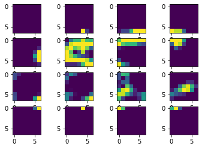

```python
for col in range(16):
  plt.subplot(4, 4, col+1)
  plt.imshow(updated_5_n[7][col].reshape(7,7))
```

```python
l5_1 = [0,1,2,3,4,5,6,7,8,9,10,11,12,13,14,15]
a5_1 =[]
for i in l5_1:
    b5_1 = updated_5_n[0,i,:].reshape(7,7)
    a5_1.append(b5_1)
c5_1=np.array(a5_1)

t5_1 = (c5_1[0], c5_1[1],c5_1[2],c5_1[3])
ct5_1 = np.concatenate(t5_1,axis=1)
r5_1 = ct5_1.reshape(-1,28)

t51_1 = (c5_1[4], c5_1[5],c5_1[6],c5_1[7])
ct51_1 = np.concatenate(t51_1,axis=1)
r51_1 = ct51_1.reshape(-1,28)

t52_1 = (c5_1[8], c5_1[9], c5_1[10],c5_1[11])
ct52_1 = np.concatenate(t52_1,axis=1)
r52_1 = ct52_1.reshape(-1,28)

t53_1 = (c5_1[12], c5_1[13], c5_1[14],c5_1[15])
ct53_1 = np.concatenate(t53_1,axis=1)
r53_1 = ct53_1.reshape(-1,28)

m5_1 = (ct5_1,ct51_1,ct52_1,ct53_1)
final_5_1 = np.concatenate(m5_1,axis=0)
final55_1 = final_5_1.reshape(-1,28,28)

####################################################
l5_2 = [0,1,2,3,4,5,6,7,8,9,10,11,12,13,14,15]
a5_2 =[]
for i in l5_2:
    b5_2 = updated_5_n[1,i,:].reshape(7,7)
    a5_2.append(b5_2)
c5_2=np.array(a5_2)

t5_2 = (c5_2[0], c5_2[1], c5_2[2],c5_2[3])
ct5_2 = np.concatenate(t5_2,axis=1)
r5_2 = ct5_2.reshape(-1,28)

t51_2 = (c5_2[4], c5_2[5],c5_2[6],c5_2[7])
ct51_2 = np.concatenate(t51_2,axis=1)
r51_2 = ct51_2.reshape(-1,28)

t52_2 = (c5_2[8], c5_2[9], c5_2[10],c5_2[11])
ct52_2 = np.concatenate(t52_2,axis=1)
r52_2 = ct52_2.reshape(-1,28)

t53_2 = (c5_2[12], c5_2[13], c5_2[14],c5_2[15])
ct53_2 = np.concatenate(t53_2,axis=1)
r53_2 = ct53_2.reshape(-1,28)

m5_2 = (ct5_2,ct51_2,ct52_2,ct53_2)
final_5_2 = np.concatenate(m5_2,axis=0)

final55_2 = final_5_2.reshape(-1,28,28)

############################################
l5_3 = [0,1,2,3,4,5,6,7,8,9,10,11,12,13,14,15]
a5_3 =[]
for i in l5_3:
    b5_3 = updated_5_n[2,i,:].reshape(7,7)
    a5_3.append(b5_3)
c5_3=np.array(a5_3)

t5_3 = (c5_3[0], c5_3[1], c5_3[2],c5_3[3])
ct5_3 = np.concatenate(t5_3,axis=1)
r5_3 = ct5_3.reshape(-1,28)

t51_3 = (c5_3[4], c5_3[5],c5_3[6],c5_3[7])
ct51_3 = np.concatenate(t51_3,axis=1)
r51_3 = ct51_3.reshape(-1,28)

t52_3 = (c5_3[8], c5_3[9], c5_3[10],c5_3[11])
ct52_3 = np.concatenate(t52_3,axis=1)
r52_3 = ct52_3.reshape(-1,28)

t53_3 = (c5_3[12], c5_3[13], c5_3[14],c5_3[15])
ct53_3 = np.concatenate(t53_3,axis=1)
r53_3 = ct53_3.reshape(-1,28)

m5_3 = (ct5_3,ct51_3,ct52_3,ct53_3)
final_5_3 = np.concatenate(m5_3,axis=0)

final55_3 = final_5_3.reshape(-1,28,28)
################################################
l5_4 = [0,1,2,3,4,5,6,7,8,9,10,11,12,13,14,15]
a5_4 =[]
for i in l5_4:
    b5_4 = updated_5_n[3,i,:].reshape(7,7)
    a5_4.append(b5_4)
c5_4=np.array(a5_4)

t5_4 = (c5_4[0], c5_4[1], c5_4[2],c5_4[3])
ct5_4 = np.concatenate(t5_4,axis=1)
r5_4 = ct5_4.reshape(-1,28)

t51_4 = (c5_4[4],c5_4[5],c5_4[6],c5_4[7])
ct51_4 = np.concatenate(t51_4,axis=1)
r51_4 = ct51_4.reshape(-1,28)

t52_4 = (c5_4[8], c5_4[9], c5_4[10],c5_4[11])
ct52_4 = np.concatenate(t52_4,axis=1)
r52_4 = ct52_4.reshape(-1,28)

t53_4 = (c5_4[12], c5_4[13],c5_4[14],c5_4[15])
ct53_4 = np.concatenate(t53_4,axis=1)
r53_4 = ct53_4.reshape(-1,28)

m5_4 = (ct5_4,ct51_4,ct52_4,ct53_4)
final_5_4 = np.concatenate(m5_4,axis=0)

final55_4 = final_5_4.reshape(-1,28,28)
##################################################

l5_5 = [0,1,2,3,4,5,6,7,8,9,10,11,12,13,14,15]
a5_5 =[]
for i in l5_5:
    b5_5 = updated_5_n[4,i,:].reshape(7,7)
    a5_5.append(b5_5)
c5_5=np.array(a5_5)

t5_5 = (c5_5[0], c5_5[1], c5_5[2],c5_5[3])
ct5_5 = np.concatenate(t5_5,axis=1)
r5_5 = ct5_5.reshape(-1,28)

t51_5 = (c5_5[4],c5_5[5],c5_5[6],c5_5[7])
ct51_5 = np.concatenate(t51_5,axis=1)
r51_5 = ct51_5.reshape(-1,28)

t52_5 = (c5_5[8], c5_5[9], c5_5[10],c5_5[11])
ct52_5 = np.concatenate(t52_5,axis=1)
r52_5 = ct52_5.reshape(-1,28)

t53_5 = (c5_5[12], c5_5[13],c5_5[14],c4_5[15])
ct53_5 = np.concatenate(t53_5,axis=1)
r53_5 = ct53_5.reshape(-1,28)

m5_5 = (ct5_5,ct51_5,ct52_5,ct53_5)
final_5_5 = np.concatenate(m5_5,axis=0)

final55_5 = final_5_5.reshape(-1,28,28)

#################################################

l5_6 = [0,1,2,3,4,5,6,7,8,9,10,11,12,13,14,15]
a5_6 =[]
for i in l5_6:
    b5_6 = updated_5_n[5,i,:].reshape(7,7)
    a5_6.append(b5_6)
c5_6=np.array(a5_6)

t5_6 = (c5_6[0], c5_6[1], c5_6[2],c5_6[3])
ct5_6 = np.concatenate(t5_6,axis=1)
r5_6 = ct5_6.reshape(-1,28)

t51_6 = (c5_6[4],c5_6[5],c5_6[6],c5_6[7])
ct51_6 = np.concatenate(t51_6,axis=1)
r51_6 = ct51_6.reshape(-1,28)

t52_6 = (c5_6[8], c5_6[9], c5_6[10],c5_6[11])
ct52_6 = np.concatenate(t52_6,axis=1)
r52_6 = ct52_6.reshape(-1,28)

t53_6 = (c5_6[12], c5_6[13],c5_6[14],c5_6[15])
ct53_6 = np.concatenate(t53_6,axis=1)
r53_6 = ct53_6.reshape(-1,28)

m5_6 = (ct5_6,ct51_6,ct52_6,ct53_6)
final_5_6 = np.concatenate(m5_6,axis=0)

final55_6 = final_5_6.reshape(-1,28,28)

#####################################################
l5_7 = [0,1,2,3,4,5,6,7,8,9,10,11,12,13,14,15]
a5_7 =[]
for i in l5_7:
    b5_7 = updated_5_n[6,i,:].reshape(7,7)
    a5_7.append(b5_7)
c5_7=np.array(a5_7)

t5_7 = (c5_7[0], c5_7[1], c5_7[2],c5_7[3])
ct5_7 = np.concatenate(t5_7,axis=1)
r5_7 = ct5_7.reshape(-1,28)

t51_7 = (c5_7[4],c5_7[5],c5_7[6],c5_7[7])
ct51_7 = np.concatenate(t51_7,axis=1)
r51_7 = ct51_7.reshape(-1,28)

t52_7 = (c5_7[8], c5_7[9],c5_7[10],c5_7[11])
ct52_7 = np.concatenate(t52_7,axis=1)
r52_7 = ct52_7.reshape(-1,28)

t53_7 = (c5_7[12], c5_7[13],c5_7[14],c5_7[15])
ct53_7 = np.concatenate(t53_7,axis=1)
r53_7 = ct53_7.reshape(-1,28)

m5_7 = (ct5_7,ct51_7,ct52_7,ct53_7)
final_5_7 = np.concatenate(m5_7,axis=0)

final55_7 = final_5_7.reshape(-1,28,28)

##################################################
l5_8 = [0,1,2,3,4,5,6,7,8,9,10,11,12,13,14,15]
a5_8 =[]
for i in l5_8:
    b5_8 = updated_5_n[7,i,:].reshape(7,7)
    a5_8.append(b5_8)
c5_8=np.array(a5_8)

t5_8 = (c5_8[0], c5_8[1], c5_8[2],c5_8[3])
ct5_8 = np.concatenate(t5_8,axis=1)
r5_8 = ct5_8.reshape(-1,28)

t51_8 = (c5_8[4],c5_8[5],c5_8[6],c5_8[7])
ct51_8 = np.concatenate(t51_8,axis=1)
r51_8 = ct51_8.reshape(-1,28)

t52_8 = (c5_8[8], c5_8[9], c5_8[10],c5_8[11])
ct52_8 = np.concatenate(t52_8,axis=1)
r52_8 = ct52_8.reshape(-1,28)

t53_8 = (c5_8[12], c5_8[13],c5_8[14],c5_8[15])
ct53_8 = np.concatenate(t53_8,axis=1)
r53_8 = ct53_8.reshape(-1,28)

m5_8 = (ct5_8,ct51_8,ct52_8,ct53_8)
final_5_8 = np.concatenate(m5_8,axis=0)

final55_8 = final_5_8.reshape(-1,28,28)

##############################################################

l5_9 = [0,1,2,3,4,5,6,7,8,9,10,11,12,13,14,15]
a5_9 =[]
for i in l5_9:
    b5_9 = updated_5_n[8,i,:].reshape(7,7)
    a5_9.append(b5_9)
c5_9=np.array(a5_9)

t5_9 = (c5_9[0], c5_9[1], c5_9[2],c5_9[3])
ct5_9 = np.concatenate(t5_9,axis=1)
r5_9 = ct5_9.reshape(-1,28)

t51_9 = (c5_9[4],c5_9[5],c5_9[6],c5_9[7])
ct51_9 = np.concatenate(t51_9,axis=1)
r51_9 = ct51_9.reshape(-1,28)

t52_9 = (c5_9[8],c5_9[9], c5_9[10],c5_9[11])
ct52_9 = np.concatenate(t52_9,axis=1)
r52_9 = ct52_9.reshape(-1,28)

t53_9 = (c5_9[12], c5_9[13],c5_9[14],c5_9[15])
ct53_9 = np.concatenate(t53_9,axis=1)
r53_9 = ct53_9.reshape(-1,28)

m5_9 = (ct5_9,ct51_9,ct52_9,ct53_9)
final_5_9 = np.concatenate(m5_9,axis=0)

final55_9 = final_5_9.reshape(-1,28,28)

###############################################
l5_a = [0,1,2,3,4,5,6,7,8,9,10,11,12,13,14,15]
a5_a =[]
for i in l5_a:
    b5_a = updated_5_n[9,i,:].reshape(7,7)
    a5_a.append(b5_a)
c5_a=np.array(a5_a)

t5_a = (c5_a[0], c5_a[1], c5_a[2],c5_a[3])
ct5_a = np.concatenate(t5_a,axis=1)
r5_a = ct5_a.reshape(-1,28)

t51_a = (c5_a[4],c5_a[5],c5_a[6],c5_a[7])
ct51_a = np.concatenate(t51_a,axis=1)
r51_a = ct51_a.reshape(-1,28)

t52_a = (c5_a[8], c5_a[9], c5_a[10],c5_a[11])
ct52_a = np.concatenate(t52_a,axis=1)
r52_a = ct52_a.reshape(-1,28)

t53_a = (c5_a[12], c5_a[13],c5_a[14],c5_a[15])
ct53_a = np.concatenate(t53_a,axis=1)
r53_a = ct53_a.reshape(-1,28)

m5_a = (ct5_a,ct51_a,ct52_a,ct53_a)
final_5_a = np.concatenate(m5_a,axis=0)

final55_a = final_5_a.reshape(-1,28,28)
```

```python
#x_0 = (final_0_1,final_01,final_0_2,final_0_3,final_0_4,final_0_5,final_0_6,final_0_7,final_0_8,final_0_9)
x_5= (final55_1,final55_2,final55_3,final55_4,final55_5,final55_6,final55_7,final55_8,final55_9,final55_a)
x_5_f = np.concatenate(x_5,axis=0)
x_5_f.shape
```

```
(10, 28, 28)
```

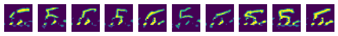

```python
D = {0,1,2,3,4,5,6,7,8,9}
#Plot the test data
fig, axs = plt.subplots(1,10,sharex=True , figsize=(10,10))
for j in D:
  axs[j].imshow(x_5_f[j],vmin=0, vmax=1)
  axs[j].axis('off')
```

Digit '7' Take 10 images from test data having their digit class as '7'. These are the original images

```
Shape of X_7 (10, 28, 28)
```

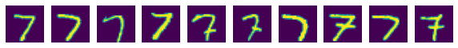

```python
# Take 10 images from test data having their digit class as '7'
X_7 = x_test[y_test == 7][:10]
print("Shape of X_7",X_7.shape)

#Plot the test data
fig, axs = plt.subplots(1,10,sharex=True , figsize=(10,10))
for j in range(10):
  axs[j].imshow(X_7[j])
  axs[j].axis('off')
```

```python
# First 8 patches for digit '7' for 10 test samples
d_7 = x_test1[y_test == 7][:10]
d_77 = d_7[:10:,0:8,:]
d_77.shape
```

```
(10, 8, 49)
```

```python
for i in range(8,16,1):
  print(f"predicting {i+1}-th frame")
  if i == 8:
    updated_7_n = np.concatenate((d_77, model.predict(d_77)[:,np.newaxis, -1,:]), axis=1)
  else:
    updated_7_n = np.concatenate((updated_7_n, model.predict(updated_7_n)[:,np.newaxis, -1,:]), axis=1)
# predicted_dict[i]
updated_7_n.shape
```

```
predicting 9-th frame
predicting 10-th frame
predicting 11-th frame
predicting 12-th frame
predicting 13-th frame
predicting 14-th frame
predicting 15-th frame
predicting 16-th frame
```

```
(10, 16, 49)
```

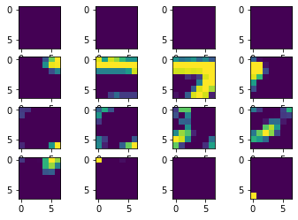

```python
for col in range(16):
  plt.subplot(4, 4, col+1)
  plt.imshow(updated_7_n[7][col].reshape(7,7))
```

```python
l7_1 = [0,1,2,3,4,5,6,7,8,9,10,11,12,13,14,15]
a7_1 =[]
for i in l7_1:
    b7_1 = updated_7_n[0,i,:].reshape(7,7)
    a7_1.append(b7_1)
c7_1=np.array(a7_1)

t7_1 = (c7_1[0], c7_1[1],c7_1[2],c7_1[3])
ct7_1 = np.concatenate(t7_1,axis=1)
r7_1 = ct7_1.reshape(-1,28)

t71_1 = (c7_1[4], c7_1[5],c7_1[6],c7_1[7])
ct71_1 = np.concatenate(t71_1,axis=1)
r71_1 = ct71_1.reshape(-1,28)

t72_1 = (c7_1[8], c7_1[9], c7_1[10],c7_1[11])
ct72_1 = np.concatenate(t72_1,axis=1)
r72_1 = ct72_1.reshape(-1,28)

t73_1 = (c7_1[12], c7_1[13], c7_1[14],c7_1[15])
ct73_1 = np.concatenate(t73_1,axis=1)
r73_1 = ct73_1.reshape(-1,28)

m7_1 = (ct7_1,ct71_1,ct72_1,ct73_1)
final_7_1 = np.concatenate(m7_1,axis=0)
final77_1 = final_7_1.reshape(-1,28,28)

####################################################
l7_2 = [0,1,2,3,4,5,6,7,8,9,10,11,12,13,14,15]
a7_2 =[]
for i in l7_2:
    b7_2 = updated_7_n[1,i,:].reshape(7,7)
    a7_2.append(b7_2)
c7_2=np.array(a7_2)

t7_2 = (c7_2[0], c7_2[1], c7_2[2],c7_2[3])
ct7_2 = np.concatenate(t7_2,axis=1)
r7_2 = ct7_2.reshape(-1,28)

t71_2 = (c7_2[4], c7_2[5],c7_2[6],c7_2[7])
ct71_2 = np.concatenate(t71_2,axis=1)
r71_2 = ct71_2.reshape(-1,28)

t72_2 = (c7_2[8], c7_2[9], c7_2[10],c7_2[11])
ct72_2 = np.concatenate(t72_2,axis=1)
r72_2 = ct72_2.reshape(-1,28)

t73_2 = (c7_2[12], c7_2[13], c7_2[14],c7_2[15])
ct73_2 = np.concatenate(t73_2,axis=1)
r73_2 = ct73_2.reshape(-1,28)

m7_2 = (ct7_2,ct71_2,ct72_2,ct73_2)
final_7_2 = np.concatenate(m7_2,axis=0)

final77_2 = final_7_2.reshape(-1,28,28)

############################################
l7_3 = [0,1,2,3,4,5,6,7,8,9,10,11,12,13,14,15]
a7_3 =[]
for i in l7_3:
    b7_3 = updated_7_n[2,i,:].reshape(7,7)
    a7_3.append(b7_3)
c7_3=np.array(a7_3)

t7_3 = (c7_3[0], c7_3[1], c7_3[2],c7_3[3])
ct7_3 = np.concatenate(t7_3,axis=1)
r7_3 = ct7_3.reshape(-1,28)

t71_3 = (c7_3[4], c7_3[5],c7_3[6],c7_3[7])
ct71_3 = np.concatenate(t71_3,axis=1)
r71_3 = ct71_3.reshape(-1,28)

t72_3 = (c7_3[8], c7_3[9], c7_3[10],c7_3[11])
ct72_3 = np.concatenate(t72_3,axis=1)
r72_3 = ct72_3.reshape(-1,28)

t73_3 = (c7_3[12], c7_3[13], c7_3[14],c7_3[15])
ct73_3 = np.concatenate(t73_3,axis=1)
r73_3 = ct73_3.reshape(-1,28)

m7_3 = (ct7_3,ct71_3,ct72_3,ct73_3)
final_7_3 = np.concatenate(m7_3,axis=0)

final77_3 = final_7_3.reshape(-1,28,28)
################################################
l7_4 = [0,1,2,3,4,5,6,7,8,9,10,11,12,13,14,15]
a7_4 =[]
for i in l7_4:
    b7_4 = updated_7_n[3,i,:].reshape(7,7)
    a7_4.append(b7_4)
c7_4=np.array(a7_4)

t7_4 = (c7_4[0], c7_4[1], c7_4[2],c7_4[3])
ct7_4 = np.concatenate(t7_4,axis=1)
r7_4 = ct7_4.reshape(-1,28)

t71_4 = (c7_4[4],c7_4[5],c7_4[6],c7_4[7])
ct71_4 = np.concatenate(t71_4,axis=1)
r71_4 = ct71_4.reshape(-1,28)

t72_4 = (c7_4[8], c7_4[9], c7_4[10],c7_4[11])
ct72_4 = np.concatenate(t72_4,axis=1)
r72_4 = ct72_4.reshape(-1,28)

t73_4 = (c7_4[12], c7_4[13],c7_4[14],c7_4[15])
ct73_4 = np.concatenate(t73_4,axis=1)
r73_4 = ct73_4.reshape(-1,28)

m7_4 = (ct7_4,ct71_4,ct72_4,ct73_4)
final_7_4 = np.concatenate(m7_4,axis=0)

final77_4 = final_7_4.reshape(-1,28,28)
##################################################

l7_5 = [0,1,2,3,4,5,6,7,8,9,10,11,12,13,14,15]
a7_5 =[]
for i in l7_5:
    b7_5 = updated_7_n[4,i,:].reshape(7,7)
    a7_5.append(b7_5)
c7_5=np.array(a7_5)

t7_5 = (c7_5[0], c7_5[1], c7_5[2],c7_5[3])
ct7_5 = np.concatenate(t7_5,axis=1)
r7_5 = ct7_5.reshape(-1,28)

t71_5 = (c7_5[4],c7_5[5],c7_5[6],c7_5[7])
ct71_5 = np.concatenate(t71_5,axis=1)
r71_5 = ct71_5.reshape(-1,28)

t72_5 = (c7_5[8], c7_5[9], c7_5[10],c7_5[11])
ct72_5 = np.concatenate(t72_5,axis=1)
r72_5 = ct72_5.reshape(-1,28)

t73_5 = (c7_5[12], c7_5[13],c7_5[14],c4_5[15])
ct73_5 = np.concatenate(t73_5,axis=1)
r73_5 = ct73_5.reshape(-1,28)

m7_5 = (ct7_5,ct71_5,ct72_5,ct73_5)
final_7_5 = np.concatenate(m7_5,axis=0)

final77_5 = final_7_5.reshape(-1,28,28)

#################################################

l7_6 = [0,1,2,3,4,5,6,7,8,9,10,11,12,13,14,15]
a7_6 =[]
for i in l7_6:
    b7_6 = updated_7_n[5,i,:].reshape(7,7)
    a7_6.append(b7_6)
c7_6=np.array(a7_6)

t7_6 = (c7_6[0], c7_6[1], c7_6[2],c7_6[3])
ct7_6 = np.concatenate(t7_6,axis=1)
r7_6 = ct7_6.reshape(-1,28)

t71_6 = (c7_6[4],c7_6[5],c7_6[6],c7_6[7])
ct71_6 = np.concatenate(t71_6,axis=1)
r71_6 = ct71_6.reshape(-1,28)

t72_6 = (c7_6[8], c7_6[9], c7_6[10],c7_6[11])
ct72_6 = np.concatenate(t72_6,axis=1)
r72_6 = ct72_6.reshape(-1,28)

t73_6 = (c7_6[12], c7_6[13],c7_6[14],c7_6[15])
ct73_6 = np.concatenate(t73_6,axis=1)
r73_6 = ct73_6.reshape(-1,28)

m7_6 = (ct7_6,ct71_6,ct72_6,ct73_6)
final_7_6 = np.concatenate(m7_6,axis=0)

final77_6 = final_7_6.reshape(-1,28,28)

#####################################################
l7_7 = [0,1,2,3,4,5,6,7,8,9,10,11,12,13,14,15]
a7_7 =[]
for i in l7_7:
    b7_7 = updated_7_n[6,i,:].reshape(7,7)
    a7_7.append(b7_7)
c7_7=np.array(a7_7)

t7_7 = (c7_7[0], c7_7[1], c7_7[2],c7_7[3])
ct7_7 = np.concatenate(t7_7,axis=1)
r7_7 = ct7_7.reshape(-1,28)

t71_7 = (c7_7[4],c7_7[5],c7_7[6],c7_7[7])
ct71_7 = np.concatenate(t71_7,axis=1)
r71_7 = ct71_7.reshape(-1,28)

t72_7 = (c7_7[8], c7_7[9],c7_7[10],c7_7[11])
ct72_7 = np.concatenate(t72_7,axis=1)
r72_7 = ct72_7.reshape(-1,28)

t73_7 = (c7_7[12], c7_7[13],c7_7[14],c7_7[15])
ct73_7 = np.concatenate(t73_7,axis=1)
r73_7 = ct73_7.reshape(-1,28)

m7_7 = (ct7_7,ct71_7,ct72_7,ct73_7)
final_7_7 = np.concatenate(m7_7,axis=0)

final77_7 = final_7_7.reshape(-1,28,28)

##################################################
l7_8 = [0,1,2,3,4,5,6,7,8,9,10,11,12,13,14,15]
a7_8 =[]
for i in l7_8:
    b7_8 = updated_7_n[7,i,:].reshape(7,7)
    a7_8.append(b7_8)
c7_8=np.array(a7_8)

t7_8 = (c7_8[0], c7_8[1], c7_8[2],c7_8[3])
ct7_8 = np.concatenate(t7_8,axis=1)
r7_8 = ct7_8.reshape(-1,28)

t71_8 = (c7_8[4],c7_8[5],c7_8[6],c7_8[7])
ct71_8 = np.concatenate(t71_8,axis=1)
r71_8 = ct71_8.reshape(-1,28)

t72_8 = (c7_8[8], c7_8[9], c7_8[10],c7_8[11])
ct72_8 = np.concatenate(t72_8,axis=1)
r72_8 = ct72_8.reshape(-1,28)

t73_8 = (c7_8[12], c7_8[13],c7_8[14],c7_8[15])
ct73_8 = np.concatenate(t73_8,axis=1)
r73_8 = ct73_8.reshape(-1,28)

m7_8 = (ct7_8,ct71_8,ct72_8,ct73_8)
final_7_8 = np.concatenate(m7_8,axis=0)

final77_8 = final_7_8.reshape(-1,28,28)

##############################################################

l7_9 = [0,1,2,3,4,5,6,7,8,9,10,11,12,13,14,15]
a7_9 =[]
for i in l7_9:
    b7_9 = updated_7_n[8,i,:].reshape(7,7)
    a7_9.append(b7_9)
c7_9=np.array(a7_9)

t7_9 = (c7_9[0], c7_9[1], c7_9[2],c7_9[3])
ct7_9 = np.concatenate(t7_9,axis=1)
r7_9 = ct7_9.reshape(-1,28)

t71_9 = (c7_9[4],c7_9[5],c7_9[6],c7_9[7])
ct71_9 = np.concatenate(t71_9,axis=1)
r71_9 = ct71_9.reshape(-1,28)

t72_9 = (c7_9[8],c7_9[9], c7_9[10],c7_9[11])
ct72_9 = np.concatenate(t72_9,axis=1)
r72_9 = ct72_9.reshape(-1,28)

t73_9 = (c7_9[12], c7_9[13],c7_9[14],c7_9[15])
ct73_9 = np.concatenate(t73_9,axis=1)
r73_9 = ct73_9.reshape(-1,28)

m7_9 = (ct7_9,ct71_9,ct72_9,ct73_9)
final_7_9 = np.concatenate(m7_9,axis=0)

final77_9 = final_7_9.reshape(-1,28,28)

###############################################
l7_a = [0,1,2,3,4,5,6,7,8,9,10,11,12,13,14,15]
a7_a =[]
for i in l7_a:
    b7_a = updated_7_n[9,i,:].reshape(7,7)
    a7_a.append(b7_a)
c7_a=np.array(a7_a)

t7_a = (c7_a[0], c7_a[1], c7_a[2],c7_a[3])
ct7_a = np.concatenate(t7_a,axis=1)
r7_a = ct7_a.reshape(-1,28)

t71_a = (c7_a[4],c7_a[5],c7_a[6],c7_a[7])
ct71_a = np.concatenate(t71_a,axis=1)
r71_a = ct71_a.reshape(-1,28)

t72_a = (c7_a[8], c7_a[9], c7_a[10],c7_a[11])
ct72_a = np.concatenate(t72_a,axis=1)
r72_a = ct72_a.reshape(-1,28)

t73_a = (c7_a[12], c7_a[13],c7_a[14],c7_a[15])
ct73_a = np.concatenate(t73_a,axis=1)
r73_a = ct73_a.reshape(-1,28)

m7_a = (ct7_a,ct71_a,ct72_a,ct73_a)
final_7_a = np.concatenate(m7_a,axis=0)

final77_a = final_7_a.reshape(-1,28,28)
```

```python
#x_0 = (final_0_1,final_01,final_0_2,final_0_3,final_0_4,final_0_5,final_0_6,final_0_7,final_0_8,final_0_9)
x_7= (final77_1,final77_2,final77_3,final77_4,final77_5,final77_6,final77_7,final77_8,final77_9,final77_a)
x_7_f = np.concatenate(x_7,axis=0)
x_7_f.shape
```

```
(10, 28, 28)
```

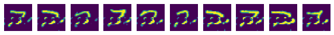

```python
D = {0,1,2,3,4,5,6,7,8,9}
#Plot the test data
fig, axs = plt.subplots(1,10,sharex=True , figsize=(10,10))
for j in D:
  axs[j].imshow(x_7_f[j],vmin=0, vmax=1)
  axs[j].axis('off')
```

Digit '8' Take 10 images from test data having their digit class as '8'. These are the original images

```
Shape of X_8 (10, 28, 28)
```

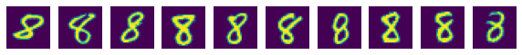

```python
# Take 10 images from test data having their digit class as '8'
X_8 = x_test[y_test == 8][:10]
print("Shape of X_8",X_8.shape)

#Plot the test data
fig, axs = plt.subplots(1,10,sharex=True , figsize=(10,10))
for j in range(10):
  axs[j].imshow(X_8[j])
  axs[j].axis('off')
```

```python
# First 8 patches for digit '8' for 10 test samples
d_8 = x_test1[y_test == 8][:10]
d_88 = d_8[:10:,0:8,:]
d_88.shape
```

```
(10, 8, 49)
```

```python
for i in range(8,16,1):
  print(f"predicting {i+1}-th frame")
  if i == 8:
    updated_8_n = np.concatenate((d_88, model.predict(d_88)[:,np.newaxis, -1,:]), axis=1)
  else:
    updated_8_n = np.concatenate((updated_8_n, model.predict(updated_8_n)[:,np.newaxis, -1,:]), axis=1)
# predicted_dict[i]
updated_8_n.shape
```

```
predicting 9-th frame
predicting 10-th frame
predicting 11-th frame
predicting 12-th frame
predicting 13-th frame
predicting 14-th frame
predicting 15-th frame
predicting 16-th frame
```

```
(10, 16, 49)
```

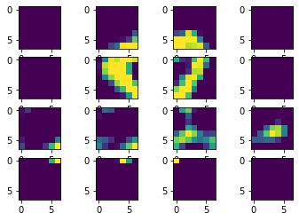

```python
for col in range(16):
  plt.subplot(4, 4, col+1)
  plt.imshow(updated_8_n[7][col].reshape(7,7))
```

```python
l8_1 = [0,1,2,3,4,5,6,7,8,9,10,11,12,13,14,15]
a8_1 =[]
for i in l8_1:
    b8_1 = updated_8_n[0,i,:].reshape(7,7)
    a8_1.append(b8_1)
c8_1=np.array(a8_1)

t8_1 = (c8_1[0], c8_1[1],c8_1[2],c8_1[3])
ct8_1 = np.concatenate(t8_1,axis=1)
r8_1 = ct8_1.reshape(-1,28)

t81_1 = (c8_1[4], c8_1[5],c8_1[6],c8_1[7])
ct81_1 = np.concatenate(t81_1,axis=1)
r81_1 = ct81_1.reshape(-1,28)

t82_1 = (c8_1[8], c8_1[9], c8_1[10],c8_1[11])
ct82_1 = np.concatenate(t82_1,axis=1)
r82_1 = ct82_1.reshape(-1,28)

t83_1 = (c8_1[12], c8_1[13], c8_1[14],c8_1[15])
ct83_1 = np.concatenate(t83_1,axis=1)
r83_1 = ct83_1.reshape(-1,28)

m8_1 = (ct8_1,ct81_1,ct82_1,ct83_1)
final_8_1 = np.concatenate(m8_1,axis=0)
final88_1 = final_8_1.reshape(-1,28,28)

####################################################
l8_2 = [0,1,2,3,4,5,6,7,8,9,10,11,12,13,14,15]
a8_2 =[]
for i in l8_2:
    b8_2 = updated_8_n[1,i,:].reshape(7,7)
    a8_2.append(b8_2)
c8_2=np.array(a8_2)

t8_2 = (c8_2[0], c8_2[1], c8_2[2],c8_2[3])
ct8_2 = np.concatenate(t8_2,axis=1)
r8_2 = ct8_2.reshape(-1,28)

t81_2 = (c8_2[4], c8_2[5],c8_2[6],c8_2[7])
ct81_2 = np.concatenate(t81_2,axis=1)
r81_2 = ct81_2.reshape(-1,28)

t82_2 = (c8_2[8], c8_2[9], c8_2[10],c8_2[11])
ct82_2 = np.concatenate(t82_2,axis=1)
r82_2 = ct82_2.reshape(-1,28)

t83_2 = (c8_2[12], c8_2[13], c8_2[14],c8_2[15])
ct83_2 = np.concatenate(t83_2,axis=1)
r83_2 = ct83_2.reshape(-1,28)

m8_2 = (ct8_2,ct81_2,ct82_2,ct83_2)
final_8_2 = np.concatenate(m8_2,axis=0)

final88_2 = final_8_2.reshape(-1,28,28)

############################################
l8_3 = [0,1,2,3,4,5,6,7,8,9,10,11,12,13,14,15]
a8_3 =[]
for i in l8_3:
    b8_3 = updated_8_n[2,i,:].reshape(7,7)
    a8_3.append(b8_3)
c8_3=np.array(a8_3)

t8_3 = (c8_3[0], c8_3[1], c8_3[2],c8_3[3])
ct8_3 = np.concatenate(t8_3,axis=1)
r8_3 = ct8_3.reshape(-1,28)

t81_3 = (c8_3[4], c8_3[5],c8_3[6],c8_3[7])
ct81_3 = np.concatenate(t81_3,axis=1)
r81_3 = ct81_3.reshape(-1,28)

t82_3 = (c8_3[8], c8_3[9], c8_3[10],c8_3[11])
ct82_3 = np.concatenate(t82_3,axis=1)
r82_3 = ct82_3.reshape(-1,28)

t83_3 = (c8_3[12], c8_3[13], c8_3[14],c8_3[15])
ct83_3 = np.concatenate(t83_3,axis=1)
r83_3 = ct83_3.reshape(-1,28)

m8_3 = (ct8_3,ct81_3,ct82_3,ct83_3)
final_8_3 = np.concatenate(m8_3,axis=0)

final88_3 = final_8_3.reshape(-1,28,28)
################################################
l8_4 = [0,1,2,3,4,5,6,7,8,9,10,11,12,13,14,15]
a8_4 =[]
for i in l8_4:
    b8_4 = updated_8_n[3,i,:].reshape(7,7)
    a8_4.append(b8_4)
c8_4=np.array(a8_4)

t8_4 = (c8_4[0], c8_4[1], c8_4[2],c8_4[3])
ct8_4 = np.concatenate(t8_4,axis=1)
r8_4 = ct8_4.reshape(-1,28)

t81_4 = (c8_4[4],c8_4[5],c8_4[6],c8_4[7])
ct81_4 = np.concatenate(t81_4,axis=1)
r81_4 = ct81_4.reshape(-1,28)

t82_4 = (c8_4[8], c8_4[9], c8_4[10],c8_4[11])
ct82_4 = np.concatenate(t82_4,axis=1)
r82_4 = ct82_4.reshape(-1,28)

t83_4 = (c8_4[12], c8_4[13],c8_4[14],c8_4[15])
ct83_4 = np.concatenate(t83_4,axis=1)
r83_4 = ct83_4.reshape(-1,28)

m8_4 = (ct8_4,ct81_4,ct82_4,ct83_4)
final_8_4 = np.concatenate(m8_4,axis=0)

final88_4 = final_8_4.reshape(-1,28,28)
##################################################

l8_5 = [0,1,2,3,4,5,6,7,8,9,10,11,12,13,14,15]
a8_5 =[]
for i in l8_5:
    b8_5 = updated_8_n[4,i,:].reshape(7,7)
    a8_5.append(b8_5)
c8_5=np.array(a8_5)

t8_5 = (c8_5[0], c8_5[1], c8_5[2],c8_5[3])
ct8_5 = np.concatenate(t8_5,axis=1)
r8_5 = ct8_5.reshape(-1,28)

t81_5 = (c8_5[4],c8_5[5],c8_5[6],c8_5[7])
ct81_5 = np.concatenate(t81_5,axis=1)
r81_5 = ct81_5.reshape(-1,28)

t82_5 = (c8_5[8], c8_5[9], c8_5[10],c8_5[11])
ct82_5 = np.concatenate(t82_5,axis=1)
r82_5 = ct82_5.reshape(-1,28)

t83_5 = (c8_5[12], c8_5[13],c8_5[14],c4_5[15])
ct83_5 = np.concatenate(t83_5,axis=1)
r83_5 = ct83_5.reshape(-1,28)

m8_5 = (ct8_5,ct81_5,ct82_5,ct83_5)
final_8_5 = np.concatenate(m8_5,axis=0)

final88_5 = final_8_5.reshape(-1,28,28)

#################################################

l8_6 = [0,1,2,3,4,5,6,7,8,9,10,11,12,13,14,15]
a8_6 =[]
for i in l8_6:
    b8_6 = updated_8_n[5,i,:].reshape(7,7)
    a8_6.append(b8_6)
c8_6=np.array(a8_6)

t8_6 = (c8_6[0], c8_6[1], c8_6[2],c8_6[3])
ct8_6 = np.concatenate(t8_6,axis=1)
r8_6 = ct8_6.reshape(-1,28)

t81_6 = (c8_6[4],c8_6[5],c8_6[6],c8_6[7])
ct81_6 = np.concatenate(t81_6,axis=1)
r81_6 = ct81_6.reshape(-1,28)

t82_6 = (c8_6[8], c8_6[9], c8_6[10],c8_6[11])
ct82_6 = np.concatenate(t82_6,axis=1)
r82_6 = ct82_6.reshape(-1,28)

t83_6 = (c8_6[12], c8_6[13],c8_6[14],c8_6[15])
ct83_6 = np.concatenate(t83_6,axis=1)
r83_6 = ct83_6.reshape(-1,28)

m8_6 = (ct8_6,ct81_6,ct82_6,ct83_6)
final_8_6 = np.concatenate(m8_6,axis=0)

final88_6 = final_8_6.reshape(-1,28,28)

#####################################################
l8_7 = [0,1,2,3,4,5,6,7,8,9,10,11,12,13,14,15]
a8_7 =[]
for i in l8_7:
    b8_7 = updated_8_n[6,i,:].reshape(7,7)
    a8_7.append(b8_7)
c8_7=np.array(a8_7)

t8_7 = (c8_7[0], c8_7[1], c8_7[2],c8_7[3])
ct8_7 = np.concatenate(t8_7,axis=1)
r8_7 = ct8_7.reshape(-1,28)

t81_7 = (c8_7[4],c8_7[5],c8_7[6],c8_7[7])
ct81_7 = np.concatenate(t81_7,axis=1)
r81_7 = ct81_7.reshape(-1,28)

t82_7 = (c8_7[8], c8_7[9],c8_7[10],c8_7[11])
ct82_7 = np.concatenate(t82_7,axis=1)
r82_7 = ct82_7.reshape(-1,28)

t83_7 = (c8_7[12], c8_7[13],c8_7[14],c8_7[15])
ct83_7 = np.concatenate(t83_7,axis=1)
r83_7 = ct83_7.reshape(-1,28)

m8_7 = (ct8_7,ct81_7,ct82_7,ct83_7)
final_8_7 = np.concatenate(m8_7,axis=0)

final88_7 = final_8_7.reshape(-1,28,28)

##################################################
l8_8 = [0,1,2,3,4,5,6,7,8,9,10,11,12,13,14,15]
a8_8 =[]
for i in l8_8:
    b8_8 = updated_8_n[7,i,:].reshape(7,7)
    a8_8.append(b8_8)
c8_8=np.array(a8_8)

t8_8 = (c8_8[0], c8_8[1], c8_8[2],c8_8[3])
ct8_8 = np.concatenate(t8_8,axis=1)
r8_8 = ct8_8.reshape(-1,28)

t81_8 = (c8_8[4],c8_8[5],c8_8[6],c8_8[7])
ct81_8 = np.concatenate(t81_8,axis=1)
r81_8 = ct81_8.reshape(-1,28)

t82_8 = (c8_8[8], c8_8[9], c8_8[10],c8_8[11])
ct82_8 = np.concatenate(t82_8,axis=1)
r82_8 = ct82_8.reshape(-1,28)

t83_8 = (c8_8[12], c8_8[13],c8_8[14],c8_8[15])
ct83_8 = np.concatenate(t83_8,axis=1)
r83_8 = ct83_8.reshape(-1,28)

m8_8 = (ct8_8,ct81_8,ct82_8,ct83_8)
final_8_8 = np.concatenate(m8_8,axis=0)

final88_8 = final_8_8.reshape(-1,28,28)

##############################################################

l8_9 = [0,1,2,3,4,5,6,7,8,9,10,11,12,13,14,15]
a8_9 =[]
for i in l8_9:
    b8_9 = updated_8_n[8,i,:].reshape(7,7)
    a8_9.append(b8_9)
c8_9=np.array(a8_9)

t8_9 = (c8_9[0], c8_9[1], c8_9[2],c8_9[3])
ct8_9 = np.concatenate(t8_9,axis=1)
r8_9 = ct8_9.reshape(-1,28)

t81_9 = (c8_9[4],c8_9[5],c8_9[6],c8_9[7])
ct81_9 = np.concatenate(t81_9,axis=1)
r81_9 = ct81_9.reshape(-1,28)

t82_9 = (c8_9[8],c8_9[9], c8_9[10],c8_9[11])
ct82_9 = np.concatenate(t82_9,axis=1)
r82_9 = ct82_9.reshape(-1,28)

t83_9 = (c8_9[12], c8_9[13],c8_9[14],c8_9[15])
ct83_9 = np.concatenate(t83_9,axis=1)
r83_9 = ct83_9.reshape(-1,28)

m8_9 = (ct8_9,ct81_9,ct82_9,ct83_9)
final_8_9 = np.concatenate(m8_9,axis=0)

final88_9 = final_8_9.reshape(-1,28,28)

###############################################
l8_a = [0,1,2,3,4,5,6,7,8,9,10,11,12,13,14,15]
a8_a =[]
for i in l8_a:
    b8_a = updated_8_n[9,i,:].reshape(7,7)
    a8_a.append(b8_a)
c8_a=np.array(a8_a)

t8_a = (c8_a[0], c8_a[1], c8_a[2],c8_a[3])
ct8_a = np.concatenate(t8_a,axis=1)
r8_a = ct8_a.reshape(-1,28)

t81_a = (c8_a[4],c8_a[5],c8_a[6],c8_a[7])
ct81_a = np.concatenate(t81_a,axis=1)
r81_a = ct81_a.reshape(-1,28)

t82_a = (c8_a[8], c8_a[9], c8_a[10],c8_a[11])
ct82_a = np.concatenate(t82_a,axis=1)
r82_a = ct82_a.reshape(-1,28)

t83_a = (c8_a[12], c8_a[13],c8_a[14],c8_a[15])
ct83_a = np.concatenate(t83_a,axis=1)
r83_a = ct83_a.reshape(-1,28)

m8_a = (ct8_a,ct81_a,ct82_a,ct83_a)
final_8_a = np.concatenate(m8_a,axis=0)

final88_a = final_8_a.reshape(-1,28,28)
```

```python
#x_0 = (final_0_1,final_01,final_0_2,final_0_3,final_0_4,final_0_5,final_0_6,final_0_7,final_0_8,final_0_9)
x_8= (final88_1,final88_2,final88_3,final88_4,final88_5,final88_6,final88_7,final88_8,final88_9,final88_a)
x_8_f = np.concatenate(x_8,axis=0)
x_8_f.shape
```

```
(10, 28, 28)
```

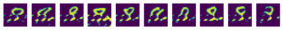

```python
D = {0,1,2,3,4,5,6,7,8,9}
#Plot the test data
fig, axs = plt.subplots(1,10,sharex=True , figsize=(10,10))
for j in D:
  axs[j].imshow(x_8_f[j],vmin=0, vmax=1)
  axs[j].axis('off')
```

Digit '9' Take 10 images from test data having their digit class as '9'. These are the original images

```
Shape of X_9 (10, 28, 28)
```

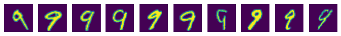

```python
# Take 10 images from test data having their digit class as '9'
X_9= x_test[y_test == 9][:10]
print("Shape of X_9",X_9.shape)

#Plot the test data
fig, axs = plt.subplots(1,10,sharex=True , figsize=(10,10))
for j in range(10):
  axs[j].imshow(X_9[j])
  axs[j].axis('off')
```

```python
# First 8 patches for digit '9' for 10 test samples
d_9 = x_test1[y_test == 9][:10]
d_99 = d_9[:10:,0:8,:]
d_99.shape
```

```
(10, 8, 49)
```

```python
for i in range(8,16,1):
  print(f"predicting {i+1}-th frame")
  if i == 8:
    updated_9_n = np.concatenate((d_99, model.predict(d_99)[:,np.newaxis, -1,:]), axis=1)
  else:
    updated_9_n = np.concatenate((updated_9_n, model.predict(updated_9_n)[:,np.newaxis, -1,:]), axis=1)
# predicted_dict[i]
updated_9_n.shape
```

```
predicting 9-th frame
predicting 10-th frame
predicting 11-th frame
predicting 12-th frame
predicting 13-th frame
predicting 14-th frame
predicting 15-th frame
predicting 16-th frame
```

```
(10, 16, 49)
```

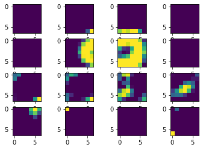

```python
for col in range(16):
  plt.subplot(4, 4, col+1)
  plt.imshow(updated_9_n[7][col].reshape(7,7))
```

```python
l9_1 = [0,1,2,3,4,5,6,7,8,9,10,11,12,13,14,15]
a9_1 =[]
for i in l9_1:
    b9_1 = updated_9_n[0,i,:].reshape(7,7)
    a9_1.append(b9_1)
c9_1=np.array(a9_1)

t9_1 = (c9_1[0], c9_1[1],c9_1[2],c9_1[3])
ct9_1 = np.concatenate(t9_1,axis=1)
r8_1 = ct9_1.reshape(-1,28)

t91_1 = (c9_1[4], c9_1[5],c9_1[6],c9_1[7])
ct91_1 = np.concatenate(t91_1,axis=1)
r81_1 = ct91_1.reshape(-1,28)

t92_1 = (c9_1[8], c9_1[9], c9_1[10],c9_1[11])
ct92_1 = np.concatenate(t92_1,axis=1)
r82_1 = ct92_1.reshape(-1,28)

t93_1 = (c9_1[12], c9_1[13], c9_1[14],c9_1[15])
ct93_1 = np.concatenate(t93_1,axis=1)
r83_1 = ct93_1.reshape(-1,28)

m9_1 = (ct9_1,ct91_1,ct92_1,ct93_1)
final_9_1 = np.concatenate(m9_1,axis=0)
final99_1 = final_9_1.reshape(-1,28,28)

####################################################
l9_2 = [0,1,2,3,4,5,6,7,8,9,10,11,12,13,14,15]
a9_2 =[]
for i in l9_2:
    b9_2 = updated_9_n[1,i,:].reshape(7,7)
    a9_2.append(b9_2)
c9_2=np.array(a9_2)

t9_2 = (c9_2[0], c9_2[1], c9_2[2],c9_2[3])
ct9_2 = np.concatenate(t9_2,axis=1)
r8_2 = ct9_2.reshape(-1,28)

t91_2 = (c9_2[4], c9_2[5],c9_2[6],c9_2[7])
ct91_2 = np.concatenate(t91_2,axis=1)
r81_2 = ct91_2.reshape(-1,28)

t92_2 = (c9_2[8], c9_2[9], c9_2[10],c9_2[11])
ct92_2 = np.concatenate(t92_2,axis=1)
r82_2 = ct92_2.reshape(-1,28)

t93_2 = (c9_2[12], c9_2[13], c9_2[14],c9_2[15])
ct93_2 = np.concatenate(t93_2,axis=1)
r83_2 = ct93_2.reshape(-1,28)

m9_2 = (ct9_2,ct91_2,ct92_2,ct93_2)
final_9_2 = np.concatenate(m9_2,axis=0)

final99_2 = final_9_2.reshape(-1,28,28)

############################################
l9_3 = [0,1,2,3,4,5,6,7,8,9,10,11,12,13,14,15]
a9_3 =[]
for i in l9_3:
    b9_3 = updated_9_n[2,i,:].reshape(7,7)
    a9_3.append(b9_3)
c9_3=np.array(a9_3)

t9_3 = (c9_3[0], c9_3[1], c9_3[2],c9_3[3])
ct9_3 = np.concatenate(t9_3,axis=1)
r8_3 = ct9_3.reshape(-1,28)

t91_3 = (c9_3[4], c9_3[5],c9_3[6],c9_3[7])
ct91_3 = np.concatenate(t91_3,axis=1)
r81_3 = ct91_3.reshape(-1,28)

t92_3 = (c9_3[8], c9_3[9], c9_3[10],c9_3[11])
ct92_3 = np.concatenate(t92_3,axis=1)
r82_3 = ct92_3.reshape(-1,28)

t93_3 = (c9_3[12], c9_3[13], c9_3[14],c9_3[15])
ct93_3 = np.concatenate(t93_3,axis=1)
r83_3 = ct93_3.reshape(-1,28)

m9_3 = (ct9_3,ct91_3,ct92_3,ct93_3)
final_9_3 = np.concatenate(m9_3,axis=0)

final99_3 = final_9_3.reshape(-1,28,28)
################################################
l9_4 = [0,1,2,3,4,5,6,7,8,9,10,11,12,13,14,15]
a9_4 =[]
for i in l9_4:
    b9_4 = updated_9_n[3,i,:].reshape(7,7)
    a9_4.append(b9_4)
c9_4=np.array(a9_4)

t9_4 = (c9_4[0], c9_4[1], c9_4[2],c9_4[3])
ct9_4 = np.concatenate(t9_4,axis=1)
r8_4 = ct9_4.reshape(-1,28)

t91_4 = (c9_4[4],c9_4[5],c9_4[6],c9_4[7])
ct91_4 = np.concatenate(t91_4,axis=1)
r81_4 = ct91_4.reshape(-1,28)

t92_4 = (c9_4[8], c9_4[9], c9_4[10],c9_4[11])
ct92_4 = np.concatenate(t92_4,axis=1)
r82_4 = ct92_4.reshape(-1,28)

t93_4 = (c9_4[12], c9_4[13],c9_4[14],c9_4[15])
ct93_4 = np.concatenate(t93_4,axis=1)
r83_4 = ct93_4.reshape(-1,28)

m9_4 = (ct9_4,ct91_4,ct92_4,ct93_4)
final_9_4 = np.concatenate(m9_4,axis=0)

final99_4 = final_9_4.reshape(-1,28,28)
##################################################

l9_5 = [0,1,2,3,4,5,6,7,8,9,10,11,12,13,14,15]
a9_5 =[]
for i in l9_5:
    b9_5 = updated_9_n[4,i,:].reshape(7,7)
    a9_5.append(b9_5)
c9_5=np.array(a9_5)

t9_5 = (c9_5[0], c9_5[1], c9_5[2],c9_5[3])
ct9_5 = np.concatenate(t9_5,axis=1)
r8_5 = ct9_5.reshape(-1,28)

t91_5 = (c9_5[4],c9_5[5],c9_5[6],c9_5[7])
ct91_5 = np.concatenate(t91_5,axis=1)
r81_5 = ct91_5.reshape(-1,28)

t92_5 = (c9_5[8], c9_5[9], c9_5[10],c9_5[11])
ct92_5 = np.concatenate(t92_5,axis=1)
r82_5 = ct92_5.reshape(-1,28)

t93_5 = (c9_5[12], c9_5[13],c9_5[14],c4_5[15])
ct93_5 = np.concatenate(t93_5,axis=1)
r83_5 = ct93_5.reshape(-1,28)

m9_5 = (ct9_5,ct91_5,ct92_5,ct93_5)
final_9_5 = np.concatenate(m9_5,axis=0)

final99_5 = final_9_5.reshape(-1,28,28)

#################################################

l9_6 = [0,1,2,3,4,5,6,7,8,9,10,11,12,13,14,15]
a9_6 =[]
for i in l9_6:
    b9_6 = updated_9_n[5,i,:].reshape(7,7)
    a9_6.append(b9_6)
c9_6=np.array(a9_6)

t9_6 = (c9_6[0], c9_6[1], c9_6[2],c9_6[3])
ct9_6 = np.concatenate(t9_6,axis=1)
r8_6 = ct9_6.reshape(-1,28)

t91_6 = (c9_6[4],c9_6[5],c9_6[6],c9_6[7])
ct91_6 = np.concatenate(t91_6,axis=1)
r81_6 = ct91_6.reshape(-1,28)

t92_6 = (c9_6[8], c9_6[9], c9_6[10],c9_6[11])
ct92_6 = np.concatenate(t92_6,axis=1)
r82_6 = ct92_6.reshape(-1,28)

t93_6 = (c9_6[12], c9_6[13],c9_6[14],c9_6[15])
ct93_6 = np.concatenate(t93_6,axis=1)
r83_6 = ct93_6.reshape(-1,28)

m9_6 = (ct9_6,ct91_6,ct92_6,ct93_6)
final_9_6 = np.concatenate(m9_6,axis=0)

final99_6 = final_9_6.reshape(-1,28,28)

#####################################################
l9_7 = [0,1,2,3,4,5,6,7,8,9,10,11,12,13,14,15]
a9_7 =[]
for i in l9_7:
    b9_7 = updated_9_n[6,i,:].reshape(7,7)
    a9_7.append(b9_7)
c9_7=np.array(a9_7)

t9_7 = (c9_7[0], c9_7[1], c9_7[2],c9_7[3])
ct9_7 = np.concatenate(t9_7,axis=1)
r8_7 = ct9_7.reshape(-1,28)

t91_7 = (c9_7[4],c9_7[5],c9_7[6],c9_7[7])
ct91_7 = np.concatenate(t91_7,axis=1)
r81_7 = ct91_7.reshape(-1,28)

t92_7 = (c9_7[8], c9_7[9],c9_7[10],c9_7[11])
ct92_7 = np.concatenate(t92_7,axis=1)
r82_7 = ct92_7.reshape(-1,28)

t93_7 = (c9_7[12], c9_7[13],c9_7[14],c9_7[15])
ct93_7 = np.concatenate(t93_7,axis=1)
r83_7 = ct93_7.reshape(-1,28)

m9_7 = (ct9_7,ct91_7,ct92_7,ct93_7)
final_9_7 = np.concatenate(m9_7,axis=0)

final99_7 = final_9_7.reshape(-1,28,28)

##################################################
l9_8 = [0,1,2,3,4,5,6,7,8,9,10,11,12,13,14,15]
a9_8 =[]
for i in l9_8:
    b9_8 = updated_9_n[7,i,:].reshape(7,7)
    a9_8.append(b9_8)
c9_8=np.array(a9_8)

t9_8 = (c9_8[0], c9_8[1], c9_8[2],c9_8[3])
ct9_8 = np.concatenate(t9_8,axis=1)
r8_8 = ct9_8.reshape(-1,28)

t91_8 = (c9_8[4],c9_8[5],c9_8[6],c9_8[7])
ct91_8 = np.concatenate(t91_8,axis=1)
r81_8 = ct91_8.reshape(-1,28)

t92_8 = (c9_8[8], c9_8[9], c9_8[10],c9_8[11])
ct92_8 = np.concatenate(t92_8,axis=1)
r82_8 = ct92_8.reshape(-1,28)

t93_8 = (c9_8[12], c9_8[13],c9_8[14],c9_8[15])
ct93_8 = np.concatenate(t93_8,axis=1)
r83_8 = ct93_8.reshape(-1,28)

m9_8 = (ct9_8,ct91_8,ct92_8,ct93_8)
final_9_8 = np.concatenate(m9_8,axis=0)

final99_8 = final_9_8.reshape(-1,28,28)

##############################################################

l9_9 = [0,1,2,3,4,5,6,7,8,9,10,11,12,13,14,15]
a9_9 =[]
for i in l9_9:
    b9_9 = updated_9_n[8,i,:].reshape(7,7)
    a9_9.append(b9_9)
c9_9=np.array(a9_9)

t9_9 = (c9_9[0], c9_9[1], c9_9[2],c9_9[3])
ct9_9 = np.concatenate(t9_9,axis=1)
r8_9 = ct9_9.reshape(-1,28)

t91_9 = (c9_9[4],c9_9[5],c9_9[6],c9_9[7])
ct91_9 = np.concatenate(t91_9,axis=1)
r81_9 = ct91_9.reshape(-1,28)

t92_9 = (c9_9[8],c9_9[9], c9_9[10],c9_9[11])
ct92_9 = np.concatenate(t92_9,axis=1)
r82_9 = ct92_9.reshape(-1,28)

t93_9 = (c9_9[12], c9_9[13],c9_9[14],c9_9[15])
ct93_9 = np.concatenate(t93_9,axis=1)
r83_9 = ct93_9.reshape(-1,28)

m9_9 = (ct9_9,ct91_9,ct92_9,ct93_9)
final_9_9 = np.concatenate(m9_9,axis=0)

final99_9 = final_9_9.reshape(-1,28,28)

###############################################
l9_a = [0,1,2,3,4,5,6,7,8,9,10,11,12,13,14,15]
a9_a =[]
for i in l9_a:
    b9_a = updated_9_n[9,i,:].reshape(7,7)
    a9_a.append(b9_a)
c9_a=np.array(a9_a)

t9_a = (c9_a[0], c9_a[1], c9_a[2],c9_a[3])
ct9_a = np.concatenate(t9_a,axis=1)
r8_a = ct9_a.reshape(-1,28)

t91_a = (c9_a[4],c9_a[5],c9_a[6],c9_a[7])
ct91_a = np.concatenate(t91_a,axis=1)
r81_a = ct91_a.reshape(-1,28)

t92_a = (c9_a[8], c9_a[9], c9_a[10],c9_a[11])
ct92_a = np.concatenate(t92_a,axis=1)
r82_a = ct92_a.reshape(-1,28)

t93_a = (c9_a[12], c9_a[13],c9_a[14],c9_a[15])
ct93_a = np.concatenate(t93_a,axis=1)
r83_a = ct93_a.reshape(-1,28)

m9_a = (ct9_a,ct91_a,ct92_a,ct93_a)
final_9_a = np.concatenate(m9_a,axis=0)

final99_a = final_9_a.reshape(-1,28,28)
```

```python
#x_0 = (final_0_1,final_01,final_0_2,final_0_3,final_0_4,final_0_5,final_0_6,final_0_7,final_0_8,final_0_9)
x_9= (final99_1,final99_2,final99_3,final99_4,final99_5,final99_6,final99_7,final99_8,final99_9,final99_a)
x_9_f = np.concatenate(x_9,axis=0)
x_9_f.shape
```

```
(10, 28, 28)
```

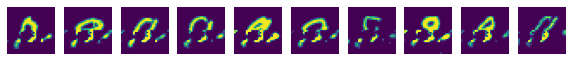

```python
D = {0,1,2,3,4,5,6,7,8,9}
#Plot the test data
fig, axs = plt.subplots(1,10,sharex=True , figsize=(10,10))
for j in D:
  axs[j].imshow(x_9_f[j],vmin=0, vmax=1)
  axs[j].axis('off')
```

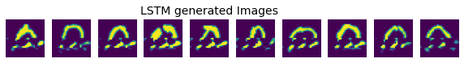

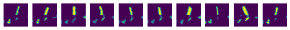

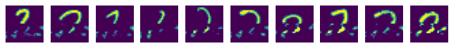

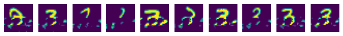

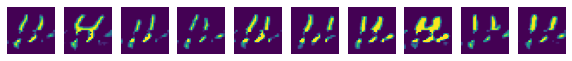

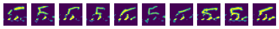

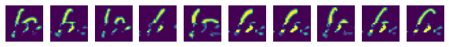

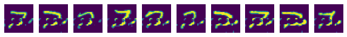

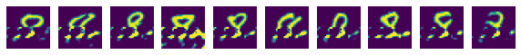

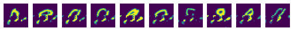

```python
########################################################
#LSTM generated images for digit '0'
D = {0,1,2,3,4,5,6,7,8,9}
#Plot the test data
fig, axs = plt.subplots(1,10,sharex=True , figsize=(10,10))
axs[4].set_title('LSTM generated Images', fontsize=14)
for j in D:
  axs[j].imshow(x_0_f[j],vmin=0, vmax=1)
  axs[j].axis('off')

########################################################
#LSTM generated images for digit '1'
D = {0,1,2,3,4,5,6,7,8,9}
#Plot the test data
fig, axs = plt.subplots(1,10,sharex=True , figsize=(10,10))
for j in D:
  axs[j].imshow(x_1_f[j],vmin=0, vmax=1)
  axs[j].axis('off')

#########################################################
#LSTM generated images for digit '2'
D = {0,1,2,3,4,5,6,7,8,9}
#Plot the test data
fig, axs = plt.subplots(1,10,sharex=True , figsize=(10,10))
for j in D:
  axs[j].imshow(x_2_f[j],vmin=0, vmax=1)
  axs[j].axis('off')
#########################################################
#LSTM generated images for digit '3'
D = {0,1,2,3,4,5,6,7,8,9}
#Plot the test data
fig, axs = plt.subplots(1,10,sharex=True , figsize=(10,10))
for j in D:
  axs[j].imshow(x_3_f[j],vmin=0, vmax=1)
  axs[j].axis('off')
########################################################
#LSTM generated images for digit '4'
D = {0,1,2,3,4,5,6,7,8,9}
#Plot the test data
fig, axs = plt.subplots(1,10,sharex=True , figsize=(10,10))
for j in D:
  axs[j].imshow(x_4_f[j],vmin=0, vmax=1)
  axs[j].axis('off')
#########################################################
#LSTM generated images for digit '5'
D = {0,1,2,3,4,5,6,7,8,9}
#Plot the test data
fig, axs = plt.subplots(1,10,sharex=True , figsize=(10,10))
for j in D:
  axs[j].imshow(x_5_f[j],vmin=0, vmax=1)
  axs[j].axis('off')
###########################################################
#LSTM generated images for digit '6'
D = {0,1,2,3,4,5,6,7,8,9}
#Plot the test data
fig, axs = plt.subplots(1,10,sharex=True , figsize=(10,10))
for j in D:
  axs[j].imshow(x_6_f[j],vmin=0, vmax=1)
  axs[j].axis('off')
###########################################################
#LSTM generated images for digit '7'
D = {0,1,2,3,4,5,6,7,8,9}
#Plot the test data
fig, axs = plt.subplots(1,10,sharex=True , figsize=(10,10))
for j in D:
  axs[j].imshow(x_7_f[j],vmin=0, vmax=1)
  axs[j].axis('off')
############################################################
#LSTM generated images for digit '8'
D = {0,1,2,3,4,5,6,7,8,9}
#Plot the test data
fig, axs = plt.subplots(1,10,sharex=True , figsize=(10,10))
for j in D:
  axs[j].imshow(x_8_f[j],vmin=0, vmax=1)
  axs[j].axis('off')
###########################################################
#LSTM generated images for digit '9'
D = {0,1,2,3,4,5,6,7,8,9}
#Plot the test data
fig, axs = plt.subplots(1,10,sharex=True , figsize=(10,10))
for j in D:
  axs[j].imshow(x_9_f[j],vmin=0, vmax=1)
  axs[j].axis('off')
```

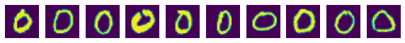

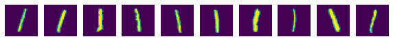

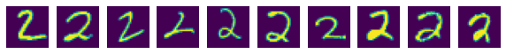

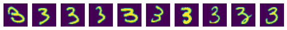

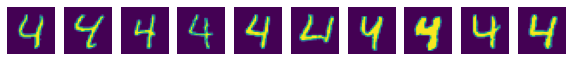

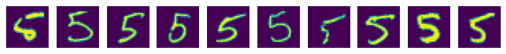

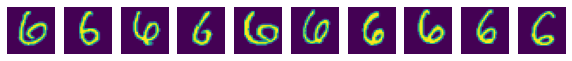

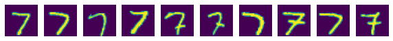

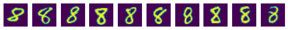

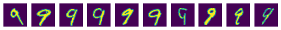

```python
###############################################################################
# Take 10 images from test data having their digit class as '0'
X_0 = x_test[y_test == 0][:10]
#Plot the test data
fig, axs = plt.subplots(1,10,sharex=True , figsize=(10,10))
for j in range(10):
  axs[j].imshow(X_0[j])
  axs[j].axis('off')

##############################################################################
# Take 10 images from test data having their digit class as '1'
X_1 = x_test[y_test == 1][:10]
#Plot the test data
fig, axs = plt.subplots(1,10,sharex=True , figsize=(10,10))
for j in range(10):
  axs[j].imshow(X_1[j])
  axs[j].axis('off')
############################################################################
# Take 10 images from test data having their digit class as '2'
X_2 = x_test[y_test == 2][:10]
#Plot the test data
fig, axs = plt.subplots(1,10,sharex=True , figsize=(10,10))
for j in range(10):
  axs[j].imshow(X_2[j])
  axs[j].axis('off')
##########################################################################
# Take 10 images from test data having their digit class as '3'
X_3 = x_test[y_test == 3][:10]
#Plot the test data
fig, axs = plt.subplots(1,10,sharex=True , figsize=(10,10))
for j in range(10):
  axs[j].imshow(X_3[j])
  axs[j].axis('off')
###########################################################################
# Take 10 images from test data having their digit class as '4'
X_4 = x_test[y_test == 4][:10]
#Plot the test data
fig, axs = plt.subplots(1,10,sharex=True , figsize=(10,10))
for j in range(10):
  axs[j].imshow(X_4[j])
  axs[j].axis('off')
########################################################################
# Take 10 images from test data having their digit class as '5'
X_5 = x_test[y_test == 5][:10]
#Plot the test data
fig, axs = plt.subplots(1,10,sharex=True , figsize=(10,10))
for j in range(10):
  axs[j].imshow(X_5[j])
  axs[j].axis('off')
########################################################################
# Take 10 images from test data having their digit class as '6'
X_6 = x_test[y_test == 6][:10]
#Plot the test data
fig, axs = plt.subplots(1,10,sharex=True , figsize=(10,10))
for j in range(10):
  axs[j].imshow(X_6[j])
  axs[j].axis('off')
########################################################################
# Take 10 images from test data having their digit class as '7'
X_7 = x_test[y_test == 7][:10]
#Plot the test data
fig, axs = plt.subplots(1,10,sharex=True , figsize=(10,10))
for j in range(10):
  axs[j].imshow(X_7[j])
  axs[j].axis('off')
########################################################################
# Take 10 images from test data having their digit class as '8'
X_8 = x_test[y_test == 8][:10]
#Plot the test data
fig, axs = plt.subplots(1,10,sharex=True , figsize=(10,10))
for j in range(10):
  axs[j].imshow(X_8[j])
  axs[j].axis('off')
########################################################################
# Take 10 images from test data having their digit class as '9'
X_9 = x_test[y_test == 9][:10]
#Plot the test data
fig, axs = plt.subplots(1,10,sharex=True , figsize=(10,10))
for j in range(10):
  axs[j].imshow(X_9[j])
  axs[j].axis('off')
```